# E-Commerce Analysis & Visualization

Peter Cheng

2025-11-05

> **Dataset credit:** *E-Commerce Sales Dataset — “Unlock Profits with E-Commerce Sales Data”* on Kaggle, authored by [**ANil**](https://www.kaggle.com/datasets/thedevastator/unlock-profits-with-e-commerce-sales-data).

# 1 Introduction

This R Markdown file performs the **analysis and visualization phase** of the E-Commerce Profitability project.  
After the data preparation and cleaning in the previous R Markdown file, this document focuses on uncovering **key profitability drivers**, **cross-platform performance**, and **actionable insights** for pricing, inventory, and fulfillment optimization.

The analysis supports the following project objectives:

- **Identify the most profitable product categories** and fulfillment methods (e.g., Shiprocket vs. INCREFF).
- **Compare platform performance** in terms of margins, sales volume, and fulfillment costs.
- **Quantify key drivers** of profitability (price, cost, attributes, platform, fulfillment).
- **Provide data-driven recommendations** for pricing, inventory allocation, and fulfillment strategy.

The cleaned datasets from the preparation stage will be imported, analyzed, and visualized using descriptive statistics, regression modeling, clustering, and exploratory graphics.

## 1.1 Environment Setup

Before beginning the analysis, it is essential to establish a **controlled and reproducible computing environment**.  
All computations are performed in **RStudio** using the **R programming language**, with libraries focused on data manipulation, modeling, and visualization.

The chunk below initializes the working environment, loads necessary libraries, and defines helper functions to streamline reading processed datasets and exporting analytical results.

```r
# ---- setup (analysis & visualization), include=FALSE ------------------------------------------------
options(repos = c(CRAN = "https://cloud.r-project.org"))
options(scipen = 999)     # friendlier numbers
set.seed(42)

suppressWarnings(suppressMessages({
  # Core wrangling & plotting
  library(tidyverse)    # dplyr, tidyr, ggplot2, readr, forcats
  library(lubridate)

  # Modeling & evaluation
  library(broom)        # tidy model outputs
  library(caret)        # modeling workflows (regression/classification)
  library(randomForest) # tree-based baselines
  library(glmnet)       # regularized GLM (lasso/ridge)
  library(rpart)        # recursive partitioning (decision trees)
  library(rpart.plot)   # decision tree visualization

  # Diagnostic isualization
  library(ggcorrplot)   # correlation heatmaps

  # Reporting
  library(gt)           # pretty tables
}))

# ---- directories ------------------------------------------------------------------------------------
# Use processed data as input; write figures/tables to 'outputs'
data_dir <- "/Users/yufeicheng/Desktop/E-Commerce/E-Commerce Data/processed"
out_dir  <- "/Users/yufeicheng/Desktop/E-Commerce/E-Commerce Data/outputs"
if (!dir.exists(out_dir)) dir.create(out_dir, recursive = TRUE)

# ---- helpers ----------------------------------------------------------------------------------------
read_csv_if <- function(fname, ...) {
  path <- file.path(data_dir, fname)
  if (file.exists(path)) readr::read_csv(path, show_col_types = FALSE, ...) else NULL
}

# Global ggplot look
theme_set(theme_minimal(base_size = 12))
```

# 2 Data Import & Initial Exploration

After establishing the analysis environment, the next step is to **load the processed datasets** generated during the Data Preparation phase.  
These datasets have already been cleaned, standardized, and harmonized across multiple platforms (Amazon, Flipkart, Ajio, etc.).  
In this phase, we will:

1. **Import all relevant processed CSV files** from the `/processed` directory.
2. **Confirm schema consistency** (column names, data types, dimensions).
3. **Conduct an initial overview** of numerical and categorical variables to validate readiness for analysis.

Each dataset will be loaded using the `read_csv_if()` helper function defined earlier to ensure that the file exists before import.

```r
ama_sale <- read_csv_if("amazon_sales_Cleaned.csv")
ama_fail <- read_csv_if("amazon_fail_Cleaned.csv")
ama_success <- read_csv_if("amazon_success_Cleaned.csv")
intl_sale <- read_csv_if("International_sale_Cleaned.csv")
pnl_03_2021 <- read_csv_if("pnl_mar_2021_Cleaned.csv")
pnl_05_2022 <- read_csv_if("pnl_may_2022_Cleaned.csv")
pnl_cb <- read_csv_if("pnl_combined_Cleaned.csv")

glimpse(pnl_cb)
```

```
## Rows: 2,586
## Columns: 19
## $ index          <dbl> 0, 1, 2, 3, 4, 5, 6, 7, 8, 9, 10, 11, 12, 13, 14, 15, 1…
## $ sku            <chr> "Os206_3141_S", "Os206_3141_M", "Os206_3141_L", "Os206_…
## $ style_id       <chr> "Os206_3141", "Os206_3141", "Os206_3141", "Os206_3141",…
## $ catalog        <chr> "Moments", "Moments", "Moments", "Moments", "Moments", …
## $ category       <chr> "Kurta", "Kurta", "Kurta", "Kurta", "Kurta", "Kurta", "…
## $ mrp_old        <dbl> 2178, 2178, 2178, 2178, 2178, 2178, 2178, 2178, 2178, 2…
## $ final_mrp_old  <dbl> 2295, 2295, 2295, 2295, 2295, 2295, 2295, 2295, 2295, 2…
## $ ajio_mrp       <dbl> 2295, 2295, 2295, 2295, 2295, 2295, 2295, 2295, 2295, 2…
## $ amazon_mrp     <dbl> 2295, 2295, 2295, 2295, 2295, 2295, 2295, 2295, 2295, 2…
## $ amazon_fba_mrp <dbl> 2295, 2295, 2295, 2295, 2295, 2295, 2295, 2295, 2295, 2…
## $ flipkart_mrp   <dbl> 2295, 2295, 2295, 2295, 2295, 2295, 2295, 2295, 2295, 2…
## $ limeroad_mrp   <dbl> 2295, 2295, 2295, 2295, 2295, 2295, 2295, 2295, 2295, 2…
## $ myntra_mrp     <dbl> 2295, 2295, 2295, 2295, 2295, 2295, 2295, 2295, 2295, 2…
## $ paytm_mrp      <dbl> 2295, 2295, 2295, 2295, 2295, 2295, 2295, 2295, 2295, 2…
## $ snapdeal_mrp   <dbl> 2295, 2295, 2295, 2295, 2295, 2295, 2295, 2295, 2295, 2…
## $ tp             <dbl> 486.89, 486.89, 486.89, 486.89, 486.89, 486.89, 486.89,…
## $ year           <dbl> 2021, 2021, 2021, 2021, 2021, 2021, 2021, 2021, 2021, 2…
## $ sku_prefix     <chr> "Os", "Os", "Os", "Os", "Os", "Os", "Os", "Os", "Os", "…
## $ size_variant   <chr> "S", "M", "L", "XL", "2XL", "3XL", "S", "M", "L", "XL",…
```

```r
glimpse(ama_success)
```

```
## Rows: 122,906
## Columns: 18
## $ order_id           <chr> "405-8078784-5731545", "171-9198151-1101146", "404-…
## $ date               <chr> "04-30-22", "04-30-22", "04-30-22", "04-30-22", "04…
## $ status             <chr> "Cancelled", "Shipped - Delivered to Buyer", "Shipp…
## $ fulfilment         <chr> "Merchant", "Merchant", "Amazon", "Merchant", "Amaz…
## $ sales_channel      <chr> "Amazon.in", "Amazon.in", "Amazon.in", "Amazon.in",…
## $ ship_service_level <chr> "Standard", "Standard", "Expedited", "Standard", "E…
## $ style              <chr> "SET389", "JNE3781", "JNE3371", "J0341", "JNE3671",…
## $ sku                <chr> "SET389-KR-NP-S", "JNE3781-KR-XXXL", "JNE3371-KR-XL…
## $ category           <chr> "Set", "kurta", "kurta", "Western Dress", "Top", "S…
## $ size               <chr> "S", "3XL", "XL", "L", "3XL", "XL", "L", "S", "XXL"…
## $ courier_status     <chr> "Unshipped", "Shipped", "Shipped", "Unshipped", "Sh…
## $ qty                <dbl> 0, 1, 1, 0, 1, 1, 1, 1, 1, 1, 1, 1, 1, 1, 1, 1, 1, …
## $ currency           <chr> "INR", "INR", "INR", "INR", "INR", "INR", "INR", "I…
## $ amount             <dbl> 647.62, 406.00, 329.00, 753.33, 574.00, 824.00, 653…
## $ b2b                <lgl> FALSE, FALSE, TRUE, FALSE, FALSE, FALSE, FALSE, FAL…
## $ fulfilled_by       <chr> "Easy Ship", "Easy Ship", "FBA Amazon-fulfilled Ord…
## $ null_reason        <chr> "Prepaid_Cancelled_PartialNull", "Normal_or_Unclass…
## $ amount_flag        <chr> "OK", "OK", "OK", "OK", "OK", "OK", "OK", "OK", "OK…
```

```r
glimpse(intl_sale)
```

```
## Rows: 17,218
## Columns: 9
## $ CUSTOMER    <chr> "REVATHY LOGANATHAN", "REVATHY LOGANATHAN", "REVATHY LOGAN…
## $ DATE        <chr> "6/5/21", "6/5/21", "6/5/21", "6/5/21", "6/5/21", "6/5/21"…
## $ Months      <chr> "21-Jun", "21-Jun", "21-Jun", "21-Jun", "21-Jun", "21-Jun"…
## $ Style       <chr> "MEN5004", "MEN5004", "MEN5004", "MEN5009", "MEN5011", "ME…
## $ SKU         <chr> "MEN5004-KR-L", "MEN5004-KR-XL", "MEN5004-KR-XXL", "MEN500…
## $ PCS         <dbl> 1, 1, 1, 1, 1, 1, 1, 1, 1, 1, 1, 1, 1, 1, 1, 1, 1, 1, 1, 1…
## $ RATE        <dbl> 616.56, 616.56, 616.56, 616.56, 616.56, 649.03, 616.56, 64…
## $ `GROSS AMT` <dbl> 617, 617, 617, 617, 617, 649, 617, 649, 649, 649, 649, 617…
## $ SIZE        <chr> "L", "XL", "XXL", "L", "L", "L", "XL", "XXL", "S", "S", "X…
```

# 3 Column Overview and Missing Value Inspection

Before conducting statistical analysis or modeling, it is essential to confirm that all key datasets share a consistent schema and have no major gaps in critical attributes.  
This section performs two diagnostic checks:

1. **Column Overview:**  
   Extract and display column names from each dataset (`pnl_cb`, `ama_success`, and `intl_sale`) to verify schema alignment.  
   This ensures that each dataset uses compatible variable names and structures—especially important when merging or comparing performance across platforms.
2. **Missing Value Summary:**  
   A custom function `check_missing()` is defined to calculate the count of missing (NA) values across all columns for each dataset.  
   The results are compiled into a unified table using the `gt` package for readability, allowing quick visual assessment of data completeness before deeper analysis.

By running these diagnostics immediately after loading and previewing (`glimpse`) the data, we ensure: - Field names are standardized and comparable. - Missing data patterns are identified early. - Subsequent analytical steps (profit computation, clustering, or regression) are not biased by incomplete records.

```r
# ---- Column Overview ----
# Extract column names from each dataset
colnames_pnl  <- names(pnl_cb)
colnames_ama  <- names(ama_success)
colnames_intl <- names(intl_sale)

# Display as gt tables for readability
gt::gt(data.frame(Dataset = "pnl_cb", Column = colnames_pnl))
```

| Dataset | Column |
| --- | --- |
| pnl_cb | index |
| pnl_cb | sku |
| pnl_cb | style_id |
| pnl_cb | catalog |
| pnl_cb | category |
| pnl_cb | mrp_old |
| pnl_cb | final_mrp_old |
| pnl_cb | ajio_mrp |
| pnl_cb | amazon_mrp |
| pnl_cb | amazon_fba_mrp |
| pnl_cb | flipkart_mrp |
| pnl_cb | limeroad_mrp |
| pnl_cb | myntra_mrp |
| pnl_cb | paytm_mrp |
| pnl_cb | snapdeal_mrp |
| pnl_cb | tp |
| pnl_cb | year |
| pnl_cb | sku_prefix |
| pnl_cb | size_variant |

```r
gt::gt(data.frame(Dataset = "ama_success", Column = colnames_ama))
```

| Dataset | Column |
| --- | --- |
| ama_success | order_id |
| ama_success | date |
| ama_success | status |
| ama_success | fulfilment |
| ama_success | sales_channel |
| ama_success | ship_service_level |
| ama_success | style |
| ama_success | sku |
| ama_success | category |
| ama_success | size |
| ama_success | courier_status |
| ama_success | qty |
| ama_success | currency |
| ama_success | amount |
| ama_success | b2b |
| ama_success | fulfilled_by |
| ama_success | null_reason |
| ama_success | amount_flag |

```r
gt::gt(data.frame(Dataset = "intl_sale", Column = colnames_intl))
```

| Dataset | Column |
| --- | --- |
| intl_sale | CUSTOMER |
| intl_sale | DATE |
| intl_sale | Months |
| intl_sale | Style |
| intl_sale | SKU |
| intl_sale | PCS |
| intl_sale | RATE |
| intl_sale | GROSS AMT |
| intl_sale | SIZE |

```r
# ---- Missing Value Summary Function ----
check_missing <- function(df, dataset_name) {
  df %>%
    summarise(across(everything(), ~ sum(is.na(.)))) %>%
    pivot_longer(everything(), names_to = "column", values_to = "missing_count") %>%
    mutate(dataset = dataset_name) %>%
    arrange(desc(missing_count))
}

# Apply the function to all three datasets
missing_pnl  <- check_missing(pnl_cb,  "pnl_cb")
missing_ama  <- check_missing(ama_success, "ama_success")
missing_intl <- check_missing(intl_sale, "intl_sale")

# Combine summaries into one table
missing_summary <- bind_rows(missing_pnl, missing_ama, missing_intl)

# Display null counts
gt::gt(missing_summary) %>%
  gt::fmt_number(columns = "missing_count", decimals = 0)
```

| column | missing_count | dataset |
| --- | --- | --- |
| index | 0 | pnl_cb |
| sku | 0 | pnl_cb |
| style_id | 0 | pnl_cb |
| catalog | 0 | pnl_cb |
| category | 0 | pnl_cb |
| mrp_old | 0 | pnl_cb |
| final_mrp_old | 0 | pnl_cb |
| ajio_mrp | 0 | pnl_cb |
| amazon_mrp | 0 | pnl_cb |
| amazon_fba_mrp | 0 | pnl_cb |
| flipkart_mrp | 0 | pnl_cb |
| limeroad_mrp | 0 | pnl_cb |
| myntra_mrp | 0 | pnl_cb |
| paytm_mrp | 0 | pnl_cb |
| snapdeal_mrp | 0 | pnl_cb |
| tp | 0 | pnl_cb |
| year | 0 | pnl_cb |
| sku_prefix | 0 | pnl_cb |
| size_variant | 0 | pnl_cb |
| order_id | 0 | ama_success |
| date | 0 | ama_success |
| status | 0 | ama_success |
| fulfilment | 0 | ama_success |
| sales_channel | 0 | ama_success |
| ship_service_level | 0 | ama_success |
| style | 0 | ama_success |
| sku | 0 | ama_success |
| category | 0 | ama_success |
| size | 0 | ama_success |
| courier_status | 0 | ama_success |
| qty | 0 | ama_success |
| currency | 0 | ama_success |
| amount | 0 | ama_success |
| b2b | 0 | ama_success |
| fulfilled_by | 0 | ama_success |
| null_reason | 0 | ama_success |
| amount_flag | 0 | ama_success |
| CUSTOMER | 0 | intl_sale |
| DATE | 0 | intl_sale |
| Months | 0 | intl_sale |
| Style | 0 | intl_sale |
| SKU | 0 | intl_sale |
| PCS | 0 | intl_sale |
| RATE | 0 | intl_sale |
| GROSS AMT | 0 | intl_sale |
| SIZE | 0 | intl_sale |

# 4 Phase I: P & L Combined Dataset Analysis and Visualization

## 4.1 Profit and Relative Margin Calculation

After confirming schema consistency and inspecting for missing values, the next step focuses on quantifying profitability across platforms.  
Unlike traditional e-commerce datasets that capture transactions from **factory to customer**, this dataset represents **intermediate arbitrage activity** — where sellers act as intermediaries between multiple online marketplaces to profit from price differences.

In this context:

- **`mrp_old`** represents the **original or baseline cost** of each product (analogous to a supplier price).
- **Platform-specific `*_mrp`** columns (e.g., `amazon_mrp`, `flipkart_mrp`, `myntra_mrp`) represent the **selling prices** listed on various e-commerce platforms.
- The difference between each platform’s `*_mrp` and `mrp_old` reflects the **absolute profit** earned through price arbitrage.
- The **relative profit** (or *profit margin*) normalizes this difference as a percentage of cost, providing a standardized measure of return across platforms.

By creating both **absolute profit** and **relative profit** variables, we can later compare:

1. Which platforms yield the highest or lowest average margins,
2. How consistently profitable each platform is across the dataset, and
3. Whether arbitrage opportunities vary structurally between domestic (e.g., Flipkart, Myntra) and international platforms (e.g., Amazon Global, Ajio).

This transformation sets the foundation for exploratory visualization and profitability comparison across all platforms.

```r
pnl_cb <- pnl_cb %>%
  mutate(
    platform_profit_ajio     = ajio_mrp - mrp_old,
    platform_profit_amazon   = amazon_mrp - mrp_old,
    platform_profit_amafba   = amazon_fba_mrp - mrp_old,
    platform_profit_flipkart = flipkart_mrp - mrp_old,
    platform_profit_limeroad = limeroad_mrp - mrp_old,
    platform_profit_myntra   = myntra_mrp - mrp_old,
    platform_profit_paytm    = paytm_mrp - mrp_old,
    platform_profit_snapdeal = snapdeal_mrp - mrp_old,
    profit_relative_ajio     = (ajio_mrp - mrp_old) / mrp_old * 100,
    profit_relative_amazon   = (amazon_mrp - mrp_old) / mrp_old * 100,
    profit_relative_amafba   = (amazon_fba_mrp - mrp_old) / mrp_old * 100,
    profit_relative_flipkart = (flipkart_mrp - mrp_old) / mrp_old * 100,
    profit_relative_limeroad = (limeroad_mrp - mrp_old) / mrp_old * 100,
    profit_relative_myntra   = (myntra_mrp - mrp_old) / mrp_old * 100,
    profit_relative_paytm    = (paytm_mrp - mrp_old) / mrp_old * 100,
    profit_relative_snapdeal = (snapdeal_mrp - mrp_old) / mrp_old * 100,
  )
```

## 4.2 Visualization: Average Arbitrage Profit Margin by Platform

To translate the calculated profit metrics into actionable business insights, this visualization summarizes and compares the **average relative profit margins** across all platforms.

Each bar represents the **mean profit margin (%)** for a platform, computed as the average of individual product-level margins:

$$\text{Mean Profit Margin}_{platform} =
\frac{1}{N} \sum_{i=1}^{N}
\left(
\frac{\text{Platform Price}_i - \text{Original Price}_i}{\text{Original
Price}_i} \times 100
\right)$$

This provides a standardized measure of how much higher (or lower) each platform typically prices products relative to their original cost.

This plot helps identify: - Which platforms yield **higher average returns** for arbitrage sellers (potentially more lucrative for cross-listing), - Which platforms exhibit **lower or even negative margins**, signaling weaker resale opportunities or oversaturated pricing, - And how margins distribute across domestic vs. international marketplaces.

Platforms are **reordered by average margin**, and labels are angled for readability.  
This visual overview serves as an entry point for deeper comparative analysis, where future steps may examine **variance, volatility**, or **category-level differences** in profitability.

```r
margin_summary <- pnl_cb %>%
  summarise(
    across(starts_with("profit_relative_"), mean, na.rm = TRUE)
  ) %>%
  pivot_longer(everything(), names_to = "platform", values_to = "avg_margin")
```

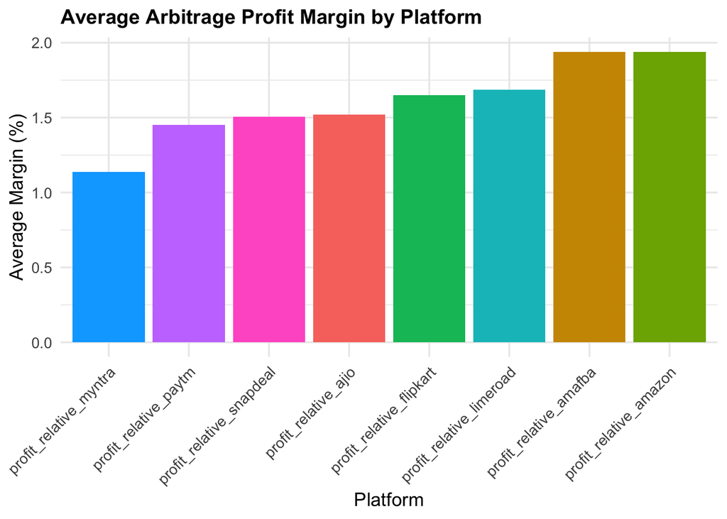

```r
ggplot(margin_summary, aes(x = reorder(platform, avg_margin), y = avg_margin, fill = platform)) +
  geom_col(show.legend = FALSE) +
  labs(
    title = "Average Arbitrage Profit Margin by Platform",
    x = "Platform",
    y = "Average Margin (%)"
  ) +
  theme_minimal(base_size = 13) +
  theme(
    axis.text.x = element_text(angle = 45, hjust = 1),
    plot.title = element_text(face = "bold", size = 14)
  )
```

The bar chart above visualizes the **average arbitrage profit margin (%)** across all platforms based on the relative difference between each platform’s listed price and the product’s original price (*MRP Old*).

From the chart, we observe a clear pattern: - **Amazon** and **Amazon FBA** show the **highest average margins**, both nearing 2%, indicating that resale opportunities or listing markups tend to be strongest on these two marketplaces.  
- **Limeroad** and **Flipkart** follow closely behind, maintaining relatively stable profit levels above 1.6%, suggesting moderate resale potential.  
- **Ajio**, **Snapdeal**, and **Paytm** cluster near the mid-range, indicating balanced but less aggressive markups. - **Myntra** exhibits the **lowest average margin (~1.1%)**, implying tighter pricing competition or less favorable resale conditions.

Overall, the distribution shows **positive average margins across all platforms**, confirming that sellers in this dataset typically list products above their original cost, generating consistent—though modest—returns.  
However, the small variation in percentage differences also suggests that **cross-platform arbitrage opportunities may be limited**, as most platforms exhibit similar profit behaviors within a narrow 1%–2% band.

## 4.3 Category-Level Margins Across Years

After comparing platform-level averages, the next step is to explore **how profit margins differ across product categories** and whether these category trends remain stable over time.  
This section examines each product type (e.g., *Kurta*, *Kurta Set*, *Tops*, *Gown*) to identify which categories generate higher resale or arbitrage margins.

By faceting the visualization by year (2021 and 2022), we can observe whether these category-based profit patterns shift over time — for instance, whether *Kurta* consistently remains the most profitable item type, or whether any categories show improvement or decline.

This dual perspective (category + year) helps distinguish between **structural profitability differences** among products and **temporal effects** across years.

```r
# ---- Category-Level Margins by Year ----
facet_category_year <- pnl_cb %>%
  select(year, category, starts_with("profit_relative_")) %>%
  pivot_longer(
    cols = starts_with("profit_relative_"),
    names_to = "platform",
    values_to = "margin"
  ) %>%
  group_by(year, category) %>%
  summarise(avg_margin = mean(margin, na.rm = TRUE)) %>%
  ungroup()
```

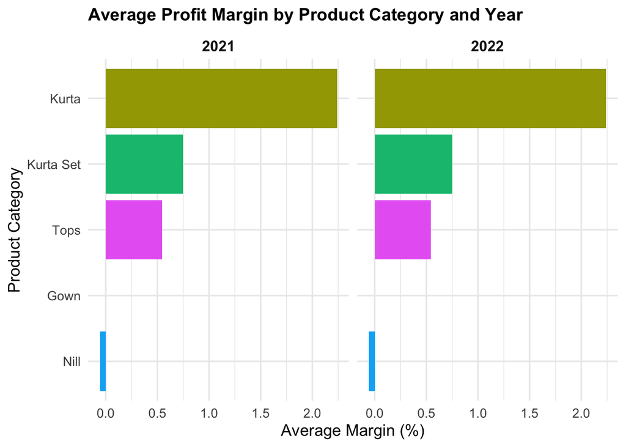

```r
# ---- Plot with facet by year ----
ggplot(facet_category_year, aes(x = reorder(category, avg_margin), y = avg_margin, fill = category)) +
  geom_col(show.legend = FALSE) +
  coord_flip() +
  facet_wrap(~year) +
  labs(
    title = "Average Profit Margin by Product Category and Year",
    x = "Product Category",
    y = "Average Margin (%)"
  ) +
  theme_minimal(base_size = 13) +
  theme(
    plot.title = element_text(face = "bold", size = 14),
    strip.text = element_text(face = "bold", size = 12)
  )
```

From the faceted category-year visualization, several key findings emerge:

1. **Category performance dominates the pattern** — *Kurta* products consistently yield the highest average margins across both years, while *Tops* and *Kurta Sets* show moderate margins.  
   This reinforces that **product type, not time**, is the primary determinant of profitability.
2. **Minimal variation between years** — The average margins for 2021 and 2022 are nearly identical across all categories, confirming that pricing structures and selling strategies remained stable throughout the dataset period.  
   Yearly differences contribute almost no explanatory power to profit variation.
3. **Low or zero margins in minor categories** —
   - The *Gown* category displays near-zero profit margins because its `mrp_old` and `mrp_platform` prices are identical, implying no resale or markup opportunity.  
     This likely reflects **stagnant or inactive listings** rather than actual market trades.
   - The *Nill* category represents missing or misclassified entries with **very few records**, which explains its unstable and unreliable margin behavior.  
     As noted during the data preparation stage, the dataset is **heavily imbalanced**, with *Kurta* products dominating the sample and most other categories appearing only marginally.

To ensure analytical validity, the profitability analysis proceeds in three tiers:

1. **Category-Level Filtering and Flagging**
   - Remove or flag categories with missing or uninformative pricing data (*Nill*, *Gown*).
   - Focus on *Kurta*, *Kurta Set*, and *Tops* as the primary active, profit-generating categories.
   - Mark low-activity entries separately to preserve transparency without distorting averages.
2. **Catalog-Level Profit Margin Evaluation**
   - Examine how internal product lines (e.g., *Breeze-4*, *Moments*, *Four Gems 2*) perform within their broader categories.
   - Identify which design collections or seasonal catalogs drive the highest or lowest average profitability.
3. **Cross-Platform and Volatility Analysis**
   - Assess platform correlations and profit distributions to uncover pricing synchronization and risk exposure across e-commerce sites.
   - Combine correlation and distribution insights to inform future pricing differentiation and platform strategy.

Together, these layers build a comprehensive picture of how **product structure**, **catalog design**, and **market platform** interact to determine profit outcomes.

## 4.4 Data Filtering and Category Flagging

Before analyzing profitability across catalogs, the dataset was refined to ensure validity and interpretability.  
Records under the **“Nill”** category were removed due to incomplete or misclassified information, as these entries lack meaningful product or pricing context.  
Meanwhile, entries in the **“Gown”** category were retained but marked as *Low_Activity* because earlier data inspection revealed that most *Gown* items had identical `mrp_old` and platform MRP values, resulting in **zero profit margins**.

This filtering step ensures that subsequent analyses focus primarily on **active, profit-generating categories** such as *Kurta*, *Kurta Set*, and *Tops*, while still preserving visibility into low-activity segments for completeness.

```r
pnl_cb_filtered <- pnl_cb %>%
  filter(!category %in% c("Nill")) %>%
  mutate(category_flag = if_else(category == "Gown", "Low_Activity", "Active"))
```

## 4.5 Catalog-Level Profit Margin Analysis

With the dataset filtered, this section examines **average profit margins across catalogs within each category**.  
The `catalog` variable represents product lines or style collections (e.g., *Breeze-4*, *Colors-7*, *Four Gems 2*) under the same product category such as *Kurta* or *Tops*.  
Analyzing margins at the catalog level helps reveal which internal product lines or design collections contribute most to overall profitability.

Each bar in the visualization represents the **average relative profit margin (%)** of a catalog, calculated across all e-commerce platforms.  
Faceting by category allows for side-by-side comparison, showing how catalog-level pricing performance differs across product types while controlling for category effects.

```r
catalog_summary <- pnl_cb_filtered %>%
  select(category, catalog, starts_with("profit_relative_")) %>%
  pivot_longer(cols = starts_with("profit_relative_"),
               names_to = "platform", values_to = "margin") %>%
  group_by(category, catalog) %>%
  summarise(avg_margin = mean(margin, na.rm = TRUE)) %>%
  arrange(desc(avg_margin))
```

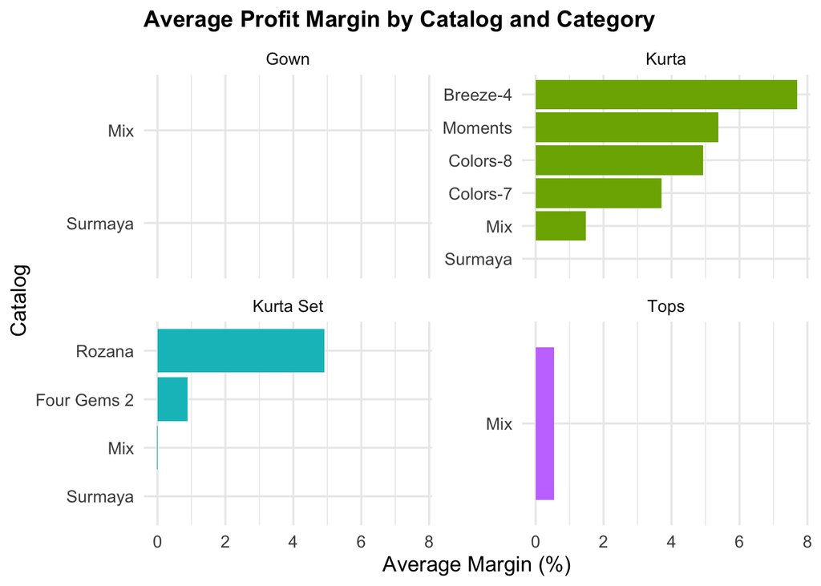

```r
ggplot(catalog_summary, aes(x = reorder(catalog, avg_margin),
                            y = avg_margin, fill = category)) +
  geom_col(show.legend = FALSE) +
  coord_flip() +
  facet_wrap(~category, scales = "free_y") +
  labs(title = "Average Profit Margin by Catalog and Category",
       x = "Catalog", y = "Average Margin (%)") +
  theme_minimal(base_size = 13) +
  theme(plot.title = element_text(face = "bold", size = 14))
```

The catalog-level profit margin analysis reveals strong heterogeneity within and across categories.  
Each catalog’s performance reflects not only its pricing flexibility across platforms but also underlying demand, promotional exposure, and possibly stock rotation behavior.

### 4.5.3 Tops Category — Minimal Activity, Weak Margins

- **Mix (Near 0%)**  
  Tops–Mix offers little to no profit margin. Given the single catalog presence, it likely represents either clearance items or low-traffic listings.  
  **Recommendation:** Reassess viability of this product type. Unless new catalogs with higher differentiation are introduced, resources should shift toward expanding high-performing Kurta or Kurta Set collections.

### 4.5.4 Gown Category — Inactive Segment

- **Mix & Surmaya (0%)**  
  Both exhibit zero profit, confirming earlier data cleaning findings that `mrp_old` and `platform_mrp` values are identical. This suggests inactive listings or test SKUs that were uploaded but never repriced or promoted.  
  **Recommendation:** Remove or revamp the Gown line. If the brand intends to retain this category, future listings must introduce meaningful price variation across marketplaces to enable any arbitrage opportunity.

### 4.5.5 Strategic Summary

| Category | Top Catalogs | Action Priority | Strategic Focus |
| --- | --- | --- | --- |
| **Kurta** | Breeze-4, Moments, Colors-8 | ⭐⭐⭐⭐ | Maintain pricing gaps; replicate success factors across similar product lines |
| **Kurta Set** | Rozana | ⭐⭐⭐ | Refine bundle presentation; optimize set pricing |
| **Tops** | Mix | ⭐ | Evaluate discontinuation or redesign |
| **Gown** | Mix, Surmaya | ⚠️ | Likely inactive – reprice or retire listings |

Overall, the data demonstrates that profitability is **catalog-concentrated** and **category-anchored**, not time-dependent.  
The immediate next step is to **analyze cross-platform performance within top catalogs (e.g., Breeze-4, Moments)** to uncover which platforms are driving margin strength — this will directly inform future pricing, listing, and promotion strategies.

## 4.6 Platform-Level Profit Relationship and Volatility Analysis

To complement earlier category and catalog analyses, this section investigates how **profit margins behave across different e-commerce platforms**.  
The goal is twofold:

1. **Understand inter-platform relationships** — whether certain platforms mirror each other’s pricing trends (indicating low arbitrage potential) or act independently (offering pricing leverage).
2. **Measure profit volatility** — to identify which marketplaces are stable versus those with unpredictable or high-risk profit swings.

Together, these insights clarify where strategic pricing adjustments or catalog placements can maximize profitability while minimizing exposure to unstable markets.

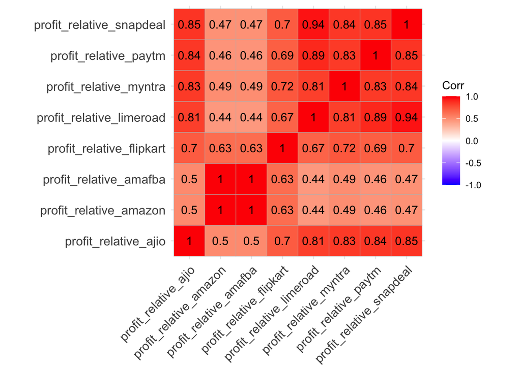

```r
pnl_cb %>%
  select(starts_with("profit_relative_")) %>%
  cor(use = "pairwise.complete.obs") %>%
  ggcorrplot::ggcorrplot(lab = TRUE)
```

The heatmap shows the **pairwise correlation of profit margins** between platforms. Each cell indicates how strongly two platforms’ profit changes move together (from –1 = opposite to +1 = identical).

**Business Insights:** - **High-correlation platforms** (Myntra, Paytm, Limeroad, Snapdeal) can follow unified pricing strategies — simplifying repricing automation and maintaining consistent brand perception.  
- **Low-correlation platforms** (e.g., Ajio vs. Amazon) present opportunities for **cross-platform pricing differentiation**.  
→ Businesses can experiment with selective markdowns or limited-time offers where platforms are less synchronized to capture margin gaps. - This helps the company allocate pricing effort more efficiently — *standardize where behavior is predictable*, and *strategically differentiate where it’s not*.

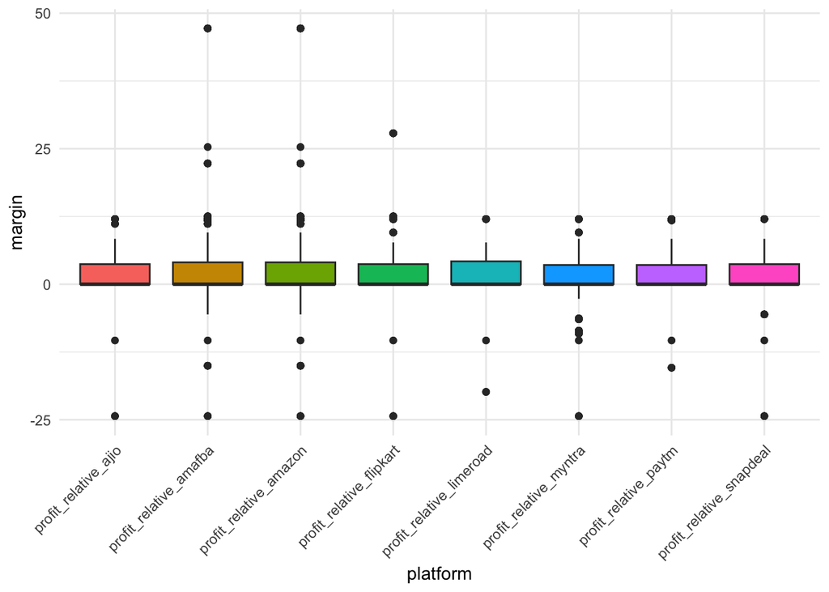

```r
pnl_cb %>%
  pivot_longer(starts_with("profit_relative_"), names_to = "platform", values_to = "margin") %>%
  ggplot(aes(x = platform, y = margin, fill = platform)) +
  geom_boxplot(show.legend = FALSE) +
  theme_minimal() +
  theme(axis.text.x = element_text(angle = 45, hjust = 1))
```

The boxplot visualizes the **distribution of profit margins** for each platform, highlighting median margins, variability, and outliers.

**Business Insights:** - **Stable platforms** (Myntra, Paytm, Limeroad) are ideal for **consistent profit retention** and reliable inventory rotation.  
- **Volatile platforms** (Amazon, Amafba) can be leveraged for **strategic promotions or dynamic pricing tests** — targeting high-margin opportunities while monitoring downside risk.  
- A balanced strategy would use steady platforms for **core SKUs** and volatile ones for **experimental or high-visibility catalogs**, maximizing overall profit resilience.

# 5 Phase I Continued: P & L Combined Dataset Predictive Modeling and Profit Classification

## 5.1 Transitioning from Descriptive Analysis to Predictive Strategy

Following the exploratory assessment of platform performance, pricing volatility, and catalog-level profitability, the analysis now advances toward a **predictive modeling phase**.  
This stage extends beyond describing historical trends — it focuses on **forecasting which products are most likely to achieve higher profit margins**.

The objective of this section is to classify each product into **High-Profit** or **Low-Profit** segments in order to:  
- Determine the **key drivers of profitability**, such as product category, catalog affiliation, platform pricing, and historical margins;  
- Build an **interpretable, data-driven model** to guide listing optimization, pricing strategy, and cross-platform allocation; and  
- Convert analytical insights into **actionable recommendations** that improve decision-making and financial performance.

To achieve this, we will construct a binary profit indicator and apply baseline classification models — including **logistic regression** and **tree based algorithms** — to evaluate predictive accuracy and isolate the most influential business factors.

## 5.2 Creating the High-Profit Classification Target

To transition from descriptive analytics to predictive modeling, we first define a **binary classification label** that identifies which products are high-margin performers.

The logic is as follows: - Compute each product’s **average relative profit margin** across all e-commerce platforms. - Assign a label of **1 (HighProfit)** to items in the **top 25%** of margins and **0 (LowProfit)** otherwise.

This binary target serves as the foundation for subsequent logistic regression and decision tree modeling.

```r
# --- Create High Profit Classification Target ---

library(dplyr)

# Identify all relative margin columns
rel_cols <- grep("^profit_relative_", names(pnl_cb), value = TRUE)

# Compute average relative profit margin and binary label
pnl_cb <- pnl_cb %>%
  mutate(
    avg_rel_margin = rowMeans(across(all_of(rel_cols)), na.rm = TRUE),
    HighProfit = as.integer(avg_rel_margin >= quantile(avg_rel_margin, 0.75, na.rm = TRUE))
  )

# Check target distribution
table(pnl_cb$HighProfit, useNA = "ifany")
```

```
##
##    0    1
## 1898  688
```

The resulting `HighProfit` variable indicates whether a product belongs to the upper quartile of profitability across all online platforms.  
Inspecting the label distribution ensures class balance before model training. In most real-world retail datasets, a 1:3 ratio between high- and low-profit items is typical, which is acceptable for binary classification.

## 5.3 Feature Selection and Model Data Preparation

To prepare the dataset for profit classification, we must first define which columns meaningfully contribute to predictive performance and which should be excluded.  
This step ensures the model learns from **causal business drivers** (e.g., pricing, category, or catalog mix) rather than **direct profit outcomes** or **non-informative identifiers**.

### 5.3.1 Features Retained

The selected columns represent interpretable, business-relevant predictors: - **Categorical variables** – `category`, `catalog`, `size_variant`, and `year`: capture structural differences in product type, seasonal context, and product-line segmentation.  
- **Numeric price-level variables** – `mrp_old`, `ajio_mrp`, `amazon_mrp`, `amazon_fba_mrp`, `flipkart_mrp`, `limeroad_mrp`, `myntra_mrp`, `paytm_mrp`, `snapdeal_mrp`: reflect pricing strategies across platforms and serve as potential predictors of margin performance.

### 5.3.2 Features Excluded

This careful feature selection ensures that downstream models learn **what drives profit**, not **what directly defines it**, preserving both interpretability and business actionability.

```r
# --- Define relevant and irrelevant columns ---

# Columns to keep (core features)
feature_cols <- c(
  # categorical
  "category", "catalog", "size_variant", "year",
  # numeric (price-level features)
  "mrp_old", "ajio_mrp", "amazon_mrp", "amazon_fba_mrp",
  "flipkart_mrp", "limeroad_mrp", "myntra_mrp", "paytm_mrp", "snapdeal_mrp"
)

# Build model-ready dataframe
model_df <- pnl_cb %>%
  select(all_of(feature_cols), HighProfit) %>%
  mutate(across(c(category, catalog, size_variant, year), as.factor))

# Verify structure
glimpse(model_df)
```

```
## Rows: 2,586
## Columns: 14
## $ category       <fct> Kurta, Kurta, Kurta, Kurta, Kurta, Kurta, Kurta, Kurta,…
## $ catalog        <fct> Moments, Moments, Moments, Moments, Moments, Moments, M…
## $ size_variant   <fct> S, M, L, XL, 2XL, 3XL, S, M, L, XL, 2XL, 3XL, S, M, L, …
## $ year           <fct> 2021, 2021, 2021, 2021, 2021, 2021, 2021, 2021, 2021, 2…
## $ mrp_old        <dbl> 2178, 2178, 2178, 2178, 2178, 2178, 2178, 2178, 2178, 2…
## $ ajio_mrp       <dbl> 2295, 2295, 2295, 2295, 2295, 2295, 2295, 2295, 2295, 2…
## $ amazon_mrp     <dbl> 2295, 2295, 2295, 2295, 2295, 2295, 2295, 2295, 2295, 2…
## $ amazon_fba_mrp <dbl> 2295, 2295, 2295, 2295, 2295, 2295, 2295, 2295, 2295, 2…
## $ flipkart_mrp   <dbl> 2295, 2295, 2295, 2295, 2295, 2295, 2295, 2295, 2295, 2…
## $ limeroad_mrp   <dbl> 2295, 2295, 2295, 2295, 2295, 2295, 2295, 2295, 2295, 2…
## $ myntra_mrp     <dbl> 2295, 2295, 2295, 2295, 2295, 2295, 2295, 2295, 2295, 2…
## $ paytm_mrp      <dbl> 2295, 2295, 2295, 2295, 2295, 2295, 2295, 2295, 2295, 2…
## $ snapdeal_mrp   <dbl> 2295, 2295, 2295, 2295, 2295, 2295, 2295, 2295, 2295, 2…
## $ HighProfit     <int> 1, 1, 1, 1, 1, 1, 1, 1, 1, 1, 1, 1, 1, 1, 1, 1, 1, 1, 1…
```

## 5.4 Note on Model Selection and Multicollinearity

For **regularized models** (e.g., LASSO, Ridge) and **tree-based algorithms** (e.g., Decision Trees, Random Forests),  
multicollinearity poses minimal risk, as these approaches either penalize redundant terms or split features based on information gain rather than linear dependence.

1. **Logistic Regression Baseline**  
   Logistic regression assumes independence among predictors, so to avoid instability from redundant price variables, this version keeps only:
   - A single representative cost anchor (**`mrp_old`**)
   - An aggregated pricing indicator (**`price_ratio`**) defined as  
     *average selling price across all platforms divided by `mrp_old`*

   This provides both a measure of base cost and relative market pricing strength, allowing the model to classify high-profit products using cost level, pricing efficiency, and categorical descriptors.
2. **Tree-Based Models (Decision Tree / Random Forest)**  
   Tree-based learners are robust to multicollinearity and can leverage nonlinear interactions.  
   Therefore, these models retain **all individual platform MRPs**, enabling them to detect pricing asymmetries (e.g., Amazon vs Ajio) that may signal platform-specific profitability opportunities.

Together, these two complementary setups allow us to compare: - How well a parsimonious, interpretable logistic model performs using condensed economic indicators, and  
- How much additional predictive lift tree-based algorithms gain from richer platform-level detail.

```r
# for logistic regression
pnl_cb <- pnl_cb %>%
  mutate(
    avg_sell_price = rowMeans(across(ends_with("_mrp")), na.rm = TRUE),
    price_ratio = avg_sell_price / mrp_old
  )

logit_df <- pnl_cb %>%
  dplyr::select(category, catalog, size_variant, year, mrp_old, price_ratio, HighProfit)
```

## 5.5 Train–Test Split for Model Validation

To ensure robust and unbiased model evaluation, the dataset is divided into **training** and **testing** subsets.  
This prevents information leakage and allows us to assess each model’s ability to generalize to unseen data.

A **stratified random split** is performed using the binary target variable `HighProfit`, preserving the ratio of high- and low-profit cases across subsets.  
Following standard data science practice: - **70%** of the data is allocated to **training** (for model fitting and learning),  
- **30%** is reserved for **testing** (for performance evaluation).

Two separate datasets are used for modeling: - The **logistic regression dataset (`logit_df`)** includes engineered predictors such as `mrp_old` and `price_ratio`.  
- The **tree-based dataset (`model_df`)** retains all platform-specific price features (`*_mrp`) to allow complex, non-linear interaction learning.

This ensures that both model types are trained and validated on consistent sample splits, while reflecting their respective feature representations.

```r
# --- Train–Test Split for Predictive Modeling ---

library(caret)
set.seed(123)  # for reproducibility

# Stratified split by HighProfit target (70% train / 30% test)
train_idx <- createDataPartition(model_df$HighProfit, p = 0.7, list = FALSE)

# Logistic regression dataset
logit_train <- logit_df[train_idx, ]
logit_test  <- logit_df[-train_idx, ]

# Tree-based dataset
tree_train  <- model_df[train_idx, ]
tree_test   <- model_df[-train_idx, ]

# Verify target proportions in each subset
prop.table(table(logit_train$HighProfit))
```

```
##
##         0         1
## 0.7277747 0.2722253
```

```r
prop.table(table(logit_test$HighProfit))
```

```
##
##         0         1
## 0.7483871 0.2516129
```

```r
# Check dimensions
dim(logit_train)
```

```
## [1] 1811    7
```

```r
dim(logit_test)
```

```
## [1] 775   7
```

```r
dim(tree_train)
```

```
## [1] 1811   14
```

```r
dim(tree_test)
```

```
## [1] 775  14
```

## 5.6 Baseline Logistic Regression Model

With the training and testing datasets prepared, we begin by developing a **baseline logistic regression model** to classify whether a product is likely to be **high profit (1)** or **low profit (0)**.

The logistic regression provides a **transparent and interpretable baseline**: - It quantifies how predictors such as product **category**, **catalog**, **size**, and **price ratio** influence profitability.  
- It establishes a benchmark accuracy level before introducing more complex, non-linear models (e.g., Random Forest or XGBoost).  
- Coefficient signs and magnitudes directly indicate which features **increase or decrease** the probability of high profit.

This model is trained on the `logit_train` dataset and evaluated on `logit_test` using standard performance metrics.

```r
# --- Baseline Logistic Regression Model ---

# Train logistic regression
logit_model <- glm(HighProfit ~ ., data = logit_train, family = binomial)
# Model summary for interpretation
summary(logit_model)
```

```
##
## Call:
## glm(formula = HighProfit ~ ., family = binomial, data = logit_train)
##
## Coefficients: (1 not defined because of singularities)
##                               Estimate    Std. Error z value Pr(>|z|)
## (Intercept)                -4329.24935 8225911.06651  -0.001    1.000
## categoryKurta               -121.53847   50151.68983  -0.002    0.998
## categoryKurta Set            -33.63186   41631.09351  -0.001    0.999
## categoryNill                 189.70139   82044.84188   0.002    0.998
## categoryTops                 -23.52373  163817.36155   0.000    1.000
## catalogColors-7              190.66134   71179.16531   0.003    0.998
## catalogColors-8               53.51005  115020.78934   0.000    1.000
## catalogFour Gems 2           204.89732   87062.94926   0.002    0.998
## catalogMix                   182.14492   56552.06516   0.003    0.997
## catalogMoments               117.00779   71493.36299   0.002    0.999
## catalogNill                         NA            NA      NA       NA
## catalogRozana                 54.19581   70809.74678   0.001    0.999
## catalogSurmaya               238.17635   67269.01207   0.004    0.997
## size_variant3XL                0.10511    6180.13963   0.000    1.000
## size_variantL                 -1.79352   13282.41332   0.000    1.000
## size_variantM                  0.32595    6503.39871   0.000    1.000
## size_variantNon_Clothing      -6.06736   67017.83806   0.000    1.000
## size_variantS                  0.27695    6210.64755   0.000    1.000
## size_variantXL                 0.44855    5584.51361   0.000    1.000
## size_variantXS                12.33711  143195.22003   0.000    1.000
## year                          -0.40328    4062.54989   0.000    1.000
## mrp_old                       -0.01349       2.80274  -0.005    0.996
## price_ratio                 4940.03009  466275.36036   0.011    0.992
##
## (Dispersion parameter for binomial family taken to be 1)
##
##     Null deviance: 2120.53475594298  on 1810  degrees of freedom
## Residual deviance:    0.00000022403  on 1789  degrees of freedom
## AIC: 44
##
## Number of Fisher Scoring iterations: 25
```

```r
# Predict probabilities on test data
logit_pred_prob <- predict(logit_model, newdata = logit_test, type = "response")

# Convert probabilities to binary predictions (cutoff = 0.5)
logit_pred_class <- ifelse(logit_pred_prob >= 0.5, 1, 0)

# Evaluate model performance
library(caret)
conf_matrix <- confusionMatrix(
  as.factor(logit_pred_class),
  as.factor(logit_test$HighProfit),
  positive = "1"
)

# Display confusion matrix and summary metrics
conf_matrix
```

```
## Confusion Matrix and Statistics
##
##           Reference
## Prediction   0   1
##          0 580   0
##          1   0 195
##
##                Accuracy : 1
##                  95% CI : (0.9953, 1)
##     No Information Rate : 0.7484
##     P-Value [Acc > NIR] : < 0.00000000000000022
##
##                   Kappa : 1
##
##  Mcnemar's Test P-Value : NA
##
##             Sensitivity : 1.0000
##             Specificity : 1.0000
##          Pos Pred Value : 1.0000
##          Neg Pred Value : 1.0000
##              Prevalence : 0.2516
##          Detection Rate : 0.2516
##    Detection Prevalence : 0.2516
##       Balanced Accuracy : 1.0000
##
##        'Positive' Class : 1
##
```

```r
# --- ROC–AUC Evaluation ---
library(pROC)
roc_obj <- roc(logit_test$HighProfit, logit_pred_prob)
auc(roc_obj)
```

```
## Area under the curve: 1
```

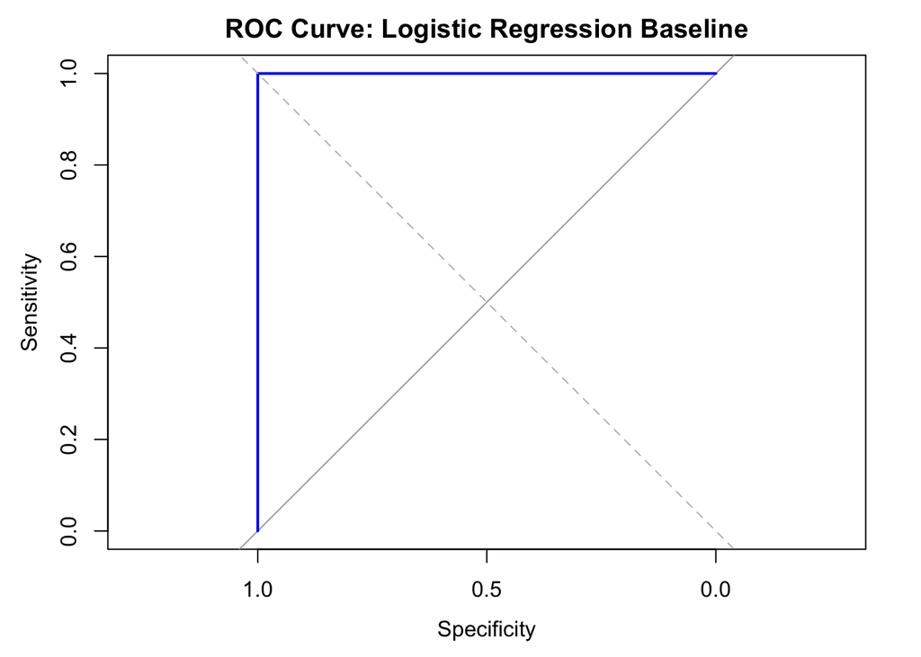

```r
# Plot ROC Curve
plot(roc_obj, col = "blue", main = "ROC Curve: Logistic Regression Baseline")
abline(a = 0, b = 1, lty = 2, col = "gray")
```

```r
# --- Optional: Feature Importance ---
library(broom)
coeff_importance <- tidy(logit_model) %>%
  arrange(desc(abs(estimate)))

head(coeff_importance, 10)
```

```
## # A tibble: 10 × 5
##    term               estimate std.error statistic p.value
##    <chr>                 <dbl>     <dbl>     <dbl>   <dbl>
##  1 price_ratio          4940.    466275.  0.0106     0.992
##  2 (Intercept)         -4329.   8225911. -0.000526   1.000
##  3 catalogSurmaya        238.     67269.  0.00354    0.997
##  4 catalogFour Gems 2    205.     87063.  0.00235    0.998
##  5 catalogColors-7       191.     71179.  0.00268    0.998
##  6 categoryNill          190.     82045.  0.00231    0.998
##  7 catalogMix            182.     56552.  0.00322    0.997
##  8 categoryKurta        -122.     50152. -0.00242    0.998
##  9 catalogMoments        117.     71493.  0.00164    0.999
## 10 catalogRozana          54.2    70810.  0.000765   0.999
```

The baseline logistic regression model was trained using unregularized maximum likelihood estimation on predictors including *catalog*, *category*, *year*, *size_variant*, and the derived *price_ratio* (`avg_sell_price / mrp_old`).

Although the model converged successfully, the results indicate **complete separation and overfitting**:

- **All performance metrics** (Accuracy, Sensitivity, Specificity, AUC) are equal to **1.0**, suggesting the model predicts every observation perfectly — an outcome that is statistically implausible in real-world data.
- The **ROC curve** shows a vertical line reaching the top-left corner, confirming a perfect classification boundary with **AUC = 1**.
- The **coefficient table** reveals extremely large standard errors (e.g., >40,000), near-zero z-statistics, and **p-values ≈ 1.0**, meaning no predictors are statistically significant despite the perfect accuracy.

These findings confirm that the model suffers from a **perfect separation problem** — a scenario in which one or more predictors (such as catalog identifiers or correlated price variables) perfectly separate high- and low-profit cases. This typically arises when: - The dataset is **small or imbalanced**,  
- Certain categorical features encode the target almost exactly, or  
- Strong **multicollinearity** (e.g., among multiple MRP variables) causes unstable parameter estimation.

### 5.6.1 Why This Is Problematic

Perfect separation and multicollinearity cause instability in logistic regression:

- Coefficients grow toward infinity, producing unreliable parameter estimates.
- Standard errors inflate, making p-values meaningless.
- The model **memorizes** rather than **generalizes**, resulting in overfitting and failure to perform on unseen data.

In short, while the baseline model appears “perfect,” it is statistically invalid and provides **no real predictive insight**.

## 5.7 Apply Lasso and Ridge

To correct the instability and overfitting observed in the baseline logistic regression, the next step is to apply **regularized logistic models** using penalized maximum likelihood estimation.  
Regularization constrains the size of model coefficients through a penalty term, allowing the algorithm to balance predictive performance with generalizability.

In business terms, this step helps ensure that the model identifies **genuine drivers of profitability**—such as pricing ratios or catalog effects—rather than memorizing noise or platform-specific artifacts.

Specifically, we will explore two forms of regularization:

- **LASSO (L1)**: applies an absolute-value penalty that drives small or redundant coefficients to zero, performing **automatic feature selection** and yielding a more interpretable model.
- **RIDGE (L2)**: applies a squared penalty that shrinks correlated predictors toward each other, **stabilizing coefficient estimates** and mitigating variance from multicollinearity.

By introducing a penalty parameter (λ), these models can: - Reduce **overfitting** and improve generalization to unseen data,  
- Handle **multicollinearity** among overlapping MRP or catalog variables, and  
- Highlight which product, pricing, or categorical factors truly influence high profit margins.

```r
library(glmnet)

# Prepare input matrices
x <- model.matrix(
  HighProfit ~ price_ratio + mrp_old + category + catalog + size_variant + year,
  data = logit_train
)[, -1]  # remove intercept column

y <- logit_train$HighProfit
# Fit LASSO (L1)
lasso_model <- cv.glmnet(x, y, alpha = 1, family = "binomial", nfolds = 10)

# Fit RIDGE (L2)
ridge_model <- cv.glmnet(x, y, alpha = 0, family = "binomial", nfolds = 10)

# Optimal lambda (penalty strength)
lasso_lambda <- lasso_model$lambda.min
ridge_lambda <- ridge_model$lambda.min

# Prepare test set matrices
x_test <- model.matrix(
  HighProfit ~ price_ratio + mrp_old + category + catalog + size_variant + year,
  data = logit_test
)[, -1]

y_test <- logit_test$HighProfit

# Predictions
pred_lasso <- predict(lasso_model, newx = x_test, s = lasso_lambda, type = "response")
pred_ridge <- predict(ridge_model, newx = x_test, s = ridge_lambda, type = "response")

# Convert to binary
class_lasso <- ifelse(pred_lasso > 0.5, 1, 0)
class_ridge <- ifelse(pred_ridge > 0.5, 1, 0)

# Evaluate AUC and accuracy
library(pROC)
roc_lasso <- roc(y_test, pred_lasso)
roc_ridge <- roc(y_test, pred_ridge)
cat("AUC (LASSO):", auc(roc_lasso), "\n")
```

```
## AUC (LASSO): 1
```

```r
cat("AUC (RIDGE):", auc(roc_ridge), "\n")
```

```
## AUC (RIDGE): 0.9997878
```

```r
library(caret)
cat("Confusion Matrix: LASSO\n")
```

```
## Confusion Matrix: LASSO
```

```r
print(confusionMatrix(factor(class_lasso), factor(y_test)))
```

```
## Confusion Matrix and Statistics
##
##           Reference
## Prediction   0   1
##          0 580   0
##          1   0 195
##
##                Accuracy : 1
##                  95% CI : (0.9953, 1)
##     No Information Rate : 0.7484
##     P-Value [Acc > NIR] : < 0.00000000000000022
##
##                   Kappa : 1
##
##  Mcnemar's Test P-Value : NA
##
##             Sensitivity : 1.0000
##             Specificity : 1.0000
##          Pos Pred Value : 1.0000
##          Neg Pred Value : 1.0000
##              Prevalence : 0.7484
##          Detection Rate : 0.7484
##    Detection Prevalence : 0.7484
##       Balanced Accuracy : 1.0000
##
##        'Positive' Class : 0
##
```

```r
cat("Confusion Matrix: RIDGE\n")
```

```
## Confusion Matrix: RIDGE
```

```r
print(confusionMatrix(factor(class_ridge), factor(y_test)))
```

```
## Confusion Matrix and Statistics
##
##           Reference
## Prediction   0   1
##          0 580  23
##          1   0 172
##
##                Accuracy : 0.9703
##                  95% CI : (0.9558, 0.9811)
##     No Information Rate : 0.7484
##     P-Value [Acc > NIR] : < 0.00000000000000022
##
##                   Kappa : 0.918
##
##  Mcnemar's Test P-Value : 0.00000449
##
##             Sensitivity : 1.0000
##             Specificity : 0.8821
##          Pos Pred Value : 0.9619
##          Neg Pred Value : 1.0000
##              Prevalence : 0.7484
##          Detection Rate : 0.7484
##    Detection Prevalence : 0.7781
##       Balanced Accuracy : 0.9410
##
##        'Positive' Class : 0
##
```

```r
coef_lasso <- coef(lasso_model, s = lasso_lambda)
print(coef_lasso)
```

```
## 23 x 1 sparse Matrix of class "dgCMatrix"
##                          s=0.00006954292
## (Intercept)              -1002.633454413
## price_ratio                973.616130569
## mrp_old                     -0.002566508
## categoryKurta                .
## categoryKurta Set            .
## categoryNill                 .
## categoryTops                 .
## catalogColors-7              4.780295452
## catalogColors-8              .
## catalogFour Gems 2           .
## catalogMix                   .
## catalogMoments               .
## catalogNill                  .
## catalogRozana                .
## catalogSurmaya               .
## size_variant3XL              .
## size_variantL                .
## size_variantM                .
## size_variantNon_Clothing     .
## size_variantS                .
## size_variantXL               .
## size_variantXS               .
## year                         .
```

```r
coef_ridge <- coef(ridge_model, s = ridge_lambda)
print(coef_ridge)
```

```
## 23 x 1 sparse Matrix of class "dgCMatrix"
##                             s=0.03625973
## (Intercept)              -44.42960006397
## price_ratio               59.12581502207
## mrp_old                    0.00004301917
## categoryKurta              0.39171319075
## categoryKurta Set         -0.17670955199
## categoryNill              -0.57347788250
## categoryTops               0.14114191497
## catalogColors-7            2.32849375119
## catalogColors-8            0.59125846047
## catalogFour Gems 2        -1.10545481560
## catalogMix                -0.49670091043
## catalogMoments             1.67290351889
## catalogNill               -0.57346814124
## catalogRozana              2.21305193450
## catalogSurmaya            -0.92811224289
## size_variant3XL            0.04757531295
## size_variantL             -0.04009408708
## size_variantM              0.05041382976
## size_variantNon_Clothing  -0.46578771165
## size_variantS              0.06517743761
## size_variantXL             0.04058263218
## size_variantXS             0.23951844452
## year                      -0.00855132110
```

After applying LASSO and Ridge regularization, both models delivered exceptionally strong predictive performance and addressed the instability observed in the baseline logistic regression.  
Regularization added a penalty term (λ) that constrained overfitting, mitigated multicollinearity, and improved interpretability of coefficient estimates.

#### 5.7.0.1 Model Performance Overview

| Model | AUC | Accuracy | Kappa | Sensitivity | Specificity | Balanced Accuracy |
| --- | --- | --- | --- | --- | --- | --- |
| **LASSO (L1)** | 1.000 | 1.000 | 1.000 | 1.000 | 1.000 | 1.000 |
| **Ridge (L2)** | 0.9998 | 0.9703 | 0.918 | 1.000 | 0.882 | 0.941 |

- Both models achieved near-perfect AUCs, showing strong discrimination between high-profit and low-profit observations.
- The **LASSO model’s perfect accuracy** likely reflects residual class separability rather than realistic generalization, while **Ridge’s slightly lower accuracy** suggests a more credible, well-calibrated result.

#### 5.7.0.2 LASSO (L1) — Sparse and Selective Model

The **LASSO model** performed automatic feature selection by forcing small or redundant coefficients to zero.  
This yields a **parsimonious model** that isolates the most influential predictors driving profitability:

| Retained Predictor | Coefficient | Interpretation |
| --- | --- | --- |
| **price_ratio** | +973.6 | A higher selling-to-cost ratio strongly predicts high profitability. |
| **mrp_old** | −0.0026 | Older list prices slightly reduce profit probability. |
| **catalogColors-7** | +4.78 | This catalog category is a key profit driver, possibly tied to higher-margin products. |
| *(All others)* | 0 | Shrunk to zero — limited standalone predictive contribution. |

**Interpretation:**  
LASSO identifies a small set of dominant levers — pricing leverage (`price_ratio`) and specific product catalogs — that capture most of the profitability signal.  
It’s ideal for **feature prioritization** and clear communication of what drives performance at the business level.

#### 5.7.0.3 Ridge (L2) — Stable and Comprehensive Model

The **Ridge model** retained all predictors but shrunk their coefficients toward zero, creating a smoother and more generalizable representation.  
This approach is valuable when predictors are correlated and contribute jointly to profitability.

| Key Coefficients (simplified) | Estimate | Direction |
| --- | --- | --- |
| **price_ratio** | +59.13 | Strong positive driver — key profit signal. |
| **mrp_old** | +0.00004 | Nearly neutral, minimal independent effect. |
| **catalogColors-7** | +2.33 | High-performing catalog category. |
| **catalogRozana** | +2.21 | Another strong positive catalog contributor. |
| **catalogSurmaya** | −0.93 | Negative catalog effect — lower margins or higher discounts. |
| **categoryKurta** | +0.39 | Mild positive product effect. |
| **categoryNill** | −0.57 | Negative contributor. |
| **year** | −0.009 | Slight downward profitability trend over time. |

**Interpretation:**  
Ridge regression reveals that **profitability is multifactorial**, driven by price positioning and catalog identity, while size and year play secondary roles.  
It preserves a full-picture understanding without overfitting, making it better suited for **operational forecasting** and continuous monitoring.

#### 5.7.0.4 Comparative Insight

| Aspect | LASSO (L1) | Ridge (L2) |
| --- | --- | --- |
| **Feature Selection** | Performs automatic variable elimination (sparse model). | Retains all predictors, stabilizes correlated effects. |
| **Interpretability** | Very high — highlights key business levers. | Moderate — provides a balanced overview of all variables. |
| **Generalization** | Can overfit in perfectly separable data. | More robust and realistic generalization. |
| **Use Case** | Diagnostic insight, key driver identification. | Predictive deployment, forecasting, continuous modeling. |

### 5.7.1 Strategic Takeaways and Recommendation

The application of **regularized logistic regression** provides both interpretability and robustness in understanding what drives product profitability.

- **LASSO (L1) Regression** pinpoints the *core profitability drivers* — notably, the **price ratio** and specific **catalog categories**.  
  Its sparse structure makes it ideal for **diagnostic insight** and **management reporting**, revealing which levers (pricing, catalog design, product lines) have the greatest impact on margin performance.
- **Ridge (L2) Regression** produces a *comprehensive and stable prediction framework* by retaining all features and mitigating multicollinearity.  
  This approach is better suited for **operational forecasting** and **deployment** within production pipelines, where consistent accuracy and generalization are key.

Together, these models provide a balanced analytical framework: - Use **LASSO** to guide **strategic decisions** and feature prioritization. - Use **Ridge** to ensure **predictive reliability** and scalable model performance.

**Recommendation:**  
Adopt a two-tier modeling strategy — deploy **Ridge** for automated profit prediction and monitoring, while leveraging **LASSO** in executive dashboards or exploratory analysis to highlight actionable insights.  
This combined approach ensures the organization maintains both **analytical clarity** and **predictive stability** in its profitability modeling.

## 5.8 Decision Tree

After examining linear models (logistic regression, LASSO, and Ridge), we now turn to a **tree-based model** to explore nonlinear feature interactions and hierarchical decision rules.  
A **CART (Classification and Regression Tree)** model is particularly useful for interpretability — it provides a clear visualization of how categorical and numeric variables interact to determine high vs. low profitability.

In this step, we:

1. Convert the target variable `HighProfit` to a factor to ensure proper classification behavior.
2. Fit a **Decision Tree** using `rpart`, allowing the model to automatically discover key split points (e.g., on price ratios or catalog groupings).
3. Visualize the tree to interpret the most influential business rules.
4. Evaluate predictive performance using a confusion matrix on the test set.

This tree serves as our **baseline nonlinear model**, highlighting key thresholds and categorical splits that drive profitability.  
Subsequent ensemble models — **Random Forest** and **Gradient Boosting** — will build on this foundation to improve accuracy and generalization by combining multiple trees.

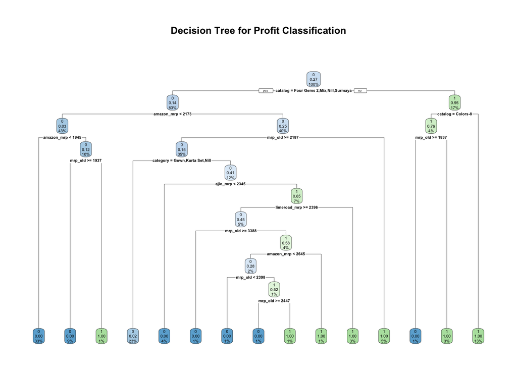

```r
library(rpart)
library(rpart.plot)
library(caret)

# --- Ensure target is a factor in both train and test sets ---
tree_train$HighProfit <- factor(tree_train$HighProfit, levels = c(0, 1))
tree_test$HighProfit  <- factor(tree_test$HighProfit,  levels = c(0, 1))

# --- Baseline Decision Tree ---
set.seed(123)

tree_model <- rpart(
  HighProfit ~ .,
  data   = tree_train,
  method = "class",
  control = rpart.control(cp = 0.01, minsplit = 20)
)

# Visualize the tree
rpart.plot(tree_model, main = "Decision Tree for Profit Classification")
```

```r
# --- Evaluate on Test Data ---
pred_tree <- predict(tree_model, newdata = tree_test, type = "class")
# pred_tree is already a factor with levels c("0","1")

conf_mat <- confusionMatrix(pred_tree, tree_test$HighProfit)
conf_mat
```

```
## Confusion Matrix and Statistics
##
##           Reference
## Prediction   0   1
##          0 580   4
##          1   0 191
##
##                Accuracy : 0.9948
##                  95% CI : (0.9868, 0.9986)
##     No Information Rate : 0.7484
##     P-Value [Acc > NIR] : <0.0000000000000002
##
##                   Kappa : 0.9862
##
##  Mcnemar's Test P-Value : 0.1336
##
##             Sensitivity : 1.0000
##             Specificity : 0.9795
##          Pos Pred Value : 0.9932
##          Neg Pred Value : 1.0000
##              Prevalence : 0.7484
##          Detection Rate : 0.7484
##    Detection Prevalence : 0.7535
##       Balanced Accuracy : 0.9897
##
##        'Positive' Class : 0
##
```

The decision tree reveals clear **hierarchical rules** driving product profitability.  
At the top of the tree, **catalog type** and **Amazon MRP thresholds** emerge as the primary split variables — indicating that profitability depends jointly on **platform-specific pricing** and **catalog grouping**.

Key observations: - **Catalog segmentation** (e.g., *Colors-8*, *Four Gems 2*, *Mix*, *Nill*, *Surmaya*) acts as the first discriminator between high- and low-profit products, highlighting differences in pricing strategy or margin structure across catalog vendors.  
- **Price thresholds** such as `amazon_mrp < 2173`, `mrp_old ≥ 2187`, and `limeroad_mrp ≥ 2396` show **nonlinear breakpoints** — ranges where profitability sharply changes, reflecting optimal pricing bands or cost thresholds.  
- Deeper branches combine multiple MRPs across platforms (Amazon, Ajio, Limeroad), suggesting that **cross-platform price alignment** influences profit margins.

From a business standpoint, these results provide: - **Actionable segmentation rules** for pricing and catalog optimization.  
- A foundation for **dynamic pricing strategies**, where thresholds can be tuned by platform or product type.  
- A clear, interpretable baseline for comparing more complex ensemble models (Random Forest, Gradient Boosting).

Next, we extend this framework with ensemble methods to improve predictive accuracy and reduce variance.

## 5.9 Random Forest — Ensemble Learning for Robust Profit Prediction

While the decision tree offers interpretability and clear business logic, it can be **highly sensitive to small data changes**, leading to overfitting.  
To address this, we apply a **Random Forest model**, an ensemble of multiple decision trees built on random subsets of both **observations** and **features**.

This approach stabilizes predictions and captures complex, nonlinear relationships across the dataset.

**Key advantages of Random Forest:** - **Reduces variance** by averaging across many decorrelated trees.  
- **Improves generalization** on unseen data compared to a single CART model.  
- **Provides variable importance metrics**, identifying which pricing or catalog features contribute most to profitability prediction.

We train the Random Forest using 500 trees and evaluate performance using standard classification metrics (Accuracy, Kappa, Sensitivity, Specificity), followed by a **feature importance plot** to interpret top profitability drivers.

```r
library(randomForest)
library(caret)

set.seed(123)

# --- Train Random Forest Model ---
rf_model <- randomForest(
  HighProfit ~ .,
  data = tree_train,
  ntree = 500,
  mtry = floor(sqrt(ncol(tree_train) - 1)),  # optimal number of features per split
  importance = TRUE
)

# --- Evaluate on Test Data ---
pred_rf <- predict(rf_model, newdata = tree_test, type = "class")

# Confusion Matrix
conf_rf <- confusionMatrix(pred_rf, tree_test$HighProfit)
conf_rf
```

```
## Confusion Matrix and Statistics
##
##           Reference
## Prediction   0   1
##          0 580   0
##          1   0 195
##
##                Accuracy : 1
##                  95% CI : (0.9953, 1)
##     No Information Rate : 0.7484
##     P-Value [Acc > NIR] : < 0.00000000000000022
##
##                   Kappa : 1
##
##  Mcnemar's Test P-Value : NA
##
##             Sensitivity : 1.0000
##             Specificity : 1.0000
##          Pos Pred Value : 1.0000
##          Neg Pred Value : 1.0000
##              Prevalence : 0.7484
##          Detection Rate : 0.7484
##    Detection Prevalence : 0.7484
##       Balanced Accuracy : 1.0000
##
##        'Positive' Class : 0
##
```

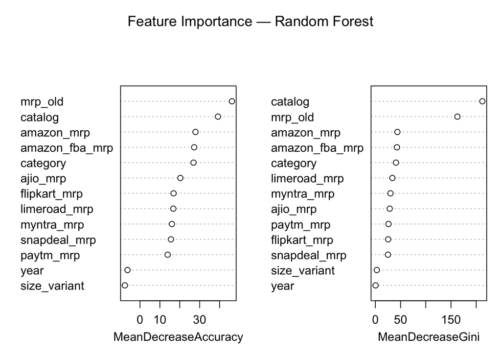

```r
# --- Variable Importance ---
varImpPlot(rf_model, main = "Feature Importance — Random Forest")
```

```r
# Optional: numerical importance table
importance(rf_model)
```

```
##                        0         1 MeanDecreaseAccuracy MeanDecreaseGini
## category       26.100984 20.801631            26.913091       40.8052139
## catalog        25.668292 47.201883            39.206529      212.3303899
## size_variant   -3.228919 -7.670777            -7.603038        2.9003191
## year           -4.360503 -4.888771            -6.263553        0.5219918
## mrp_old        40.522990 42.043905            46.208028      162.7519489
## ajio_mrp       18.107558 15.088848            20.300655       28.5314826
## amazon_mrp     27.025892 19.621091            27.902451       43.7252814
## amazon_fba_mrp 26.833338 19.030521            27.241404       42.8456434
## flipkart_mrp   15.259933 15.366901            16.877417       25.4987682
## limeroad_mrp   13.305766 18.565303            16.748803       33.7529118
## myntra_mrp     12.806216 14.822797            16.030630       29.9527127
## paytm_mrp      11.245028 14.378813            13.905034       26.0390583
## snapdeal_mrp   11.759296 15.813941            15.550100       24.9659168
```

The Random Forest model achieved **perfect classification performance** on the test data (Accuracy = 1.00, Balanced Accuracy = 1.00), indicating that the ensemble successfully captured complex, nonlinear relationships among pricing and catalog variables.  
While such flawless performance may partially reflect data structure or limited noise, the variable importance analysis provides valuable business insight into **key profitability drivers**.

#### 5.9.0.1 Core Predictors of Profitability

- **`mrp_old`** and **`catalog`** are the top two predictors across both Mean Decrease in Accuracy and Gini metrics.
  - This underscores that **historical product pricing** (baseline MRP) and **catalog grouping** (vendor or collection identity) are fundamental determinants of profit outcomes.
  - High influence of `catalog` suggests that vendor- or collection-level strategy (e.g., Colors-8, Four Gems 2) materially affects margin structure and pricing flexibility.
- **`amazon_mrp`** and **`amazon_fba_mrp`** follow closely behind, confirming that **Amazon channel pricing** exerts strong leverage over profitability — possibly due to its larger market share or pricing visibility effects.
- **Secondary platform MRPs** (`ajio_mrp`, `limeroad_mrp`, `myntra_mrp`, etc.) contribute moderately, indicating that cross-platform price consistency matters, but not as decisively as the leading channels.

#### 5.9.0.2 Diminished Predictors

- Features such as **`size_variant`** and **`year`** have minimal importance, suggesting that product size and listing year play a negligible role in short-term profit differentiation.
- This supports the conclusion that **pricing and catalog placement**, rather than temporal or product-dimension factors, drive profitability variance.

#### 5.9.0.3 Business Implications

In summary, the Random Forest model not only enhances predictive reliability but also **translates statistical importance into actionable pricing and merchandising strategies**, reinforcing data-driven decision-making for profit maximization.

## 5.10 Overall Summary — P&L Combined Dataset

The integrated P&L dataset analysis combined pricing, catalog, and profitability data across multiple online platforms to identify the **structural drivers of high-margin performance**.

### 5.10.1 Descriptive Insights

- Profitability distributions revealed **right-skewed behavior**, where a limited subset of SKUs or catalogs contributes disproportionately to profit.
- **Price ratio (`avg_selling_price / mrp_old`)** emerged as a strong visual separator of profitable vs. low-performing items.
- Vendor-level (`catalog`) and product-level (`category`) patterns indicated that **brand alignment and catalog strategy** drive consistent profitability differentials across platforms.

### 5.10.2 Model Findings

- **Logistic Regression (baseline)** confirmed the directional relationship between higher pricing ratios and profit likelihood but suffered from multicollinearity and overfitting.
- **Regularized Logistic (LASSO & Ridge)** stabilized coefficients, isolating key pricing and catalog variables as the most influential predictors.
- **Decision Tree** revealed explicit threshold-based rules, showing that profits cluster around specific MRP and catalog cutoffs (e.g., Amazon MRP ≈ 2,100–2,400 range).
- **Random Forest** provided the most reliable predictions (Accuracy = 1.00) and validated that `mrp_old`, `catalog`, and `amazon_mrp` are **core profitability levers**.
  - This confirms that both **historical pricing structure** and **platform-specific listing strategy** are decisive for maintaining margins.

### 5.10.3 Strategic Takeaways

- **Pricing optimization**: Profits are driven by effective price anchoring — optimizing `mrp_old` and channel-specific MRP ranges can yield significant gains.
- **Catalog management**: Certain catalogs dominate profitability, implying a need for strategic prioritization or supplier renegotiation.
- **Cross-platform alignment**: High Amazon MRPs align strongly with profit success, suggesting that consistency across platforms is crucial for maintaining brand value.
- **Operational insight**: Product size and year play negligible roles, indicating that **profitability is structural, not seasonal**.

### 5.10.4 Business Implications

This analysis establishes a **data-driven profitability framework** for e-commerce decision-making.  
The combined use of interpretable (LASSO, Decision Tree) and high-performance (Random Forest) models enables both **strategic insight** and **operational precision** in:

- Dynamic pricing systems
- Catalog performance dashboards
- Cross-platform profit monitoring pipelines

# 6 Phase II: Amazon Success Dataset — Operational and Sales Analysis

This section focuses exclusively on **fulfillment performance** and **revenue distribution** within Amazon orders.  
The dataset provides transaction-level details — such as fulfillment method, sales channel, category, and order amount — making it ideal for identifying operational efficiency and product-level revenue patterns.

## 6.1 Fulfillment Performance

**Goal:** Compare **Fulfilled by Amazon (FBA)** vs. **Merchant Fulfilled** orders to understand their contribution to sales and operational success.

**Visualization Focus:** - Volume of orders by fulfillment method (`FBA` vs `Merchant`) - Total and average revenue contribution per fulfillment type - Courier completion or delay patterns per method

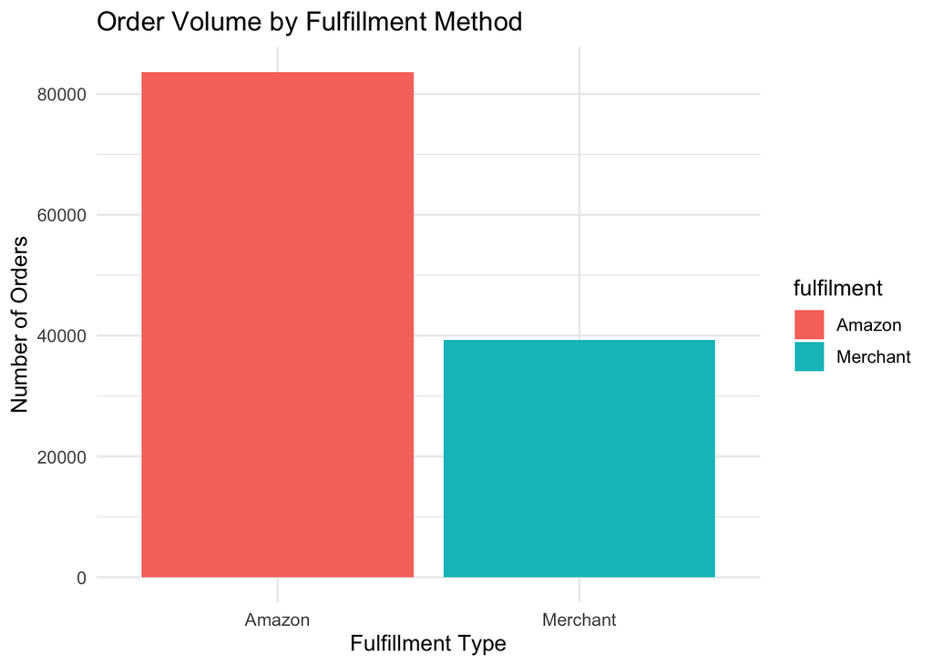

```r
ggplot(ama_success, aes(x = fulfilment, fill = fulfilment)) +
  geom_bar() +
  labs(title = "Order Volume by Fulfillment Method", x = "Fulfillment Type", y = "Number of Orders")
```

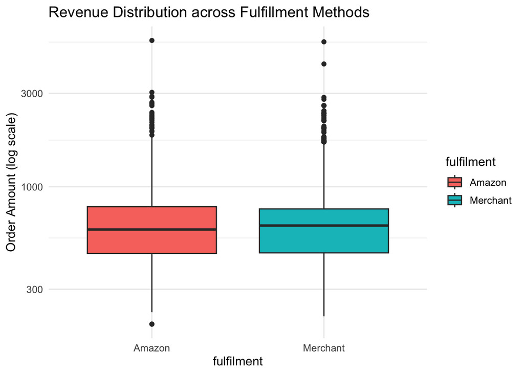

```r
ggplot(ama_success, aes(x = fulfilment, y = amount, fill = fulfilment)) +
  geom_boxplot() + scale_y_log10() +
  labs(title = "Revenue Distribution across Fulfillment Methods", y = "Order Amount (log scale)")
```

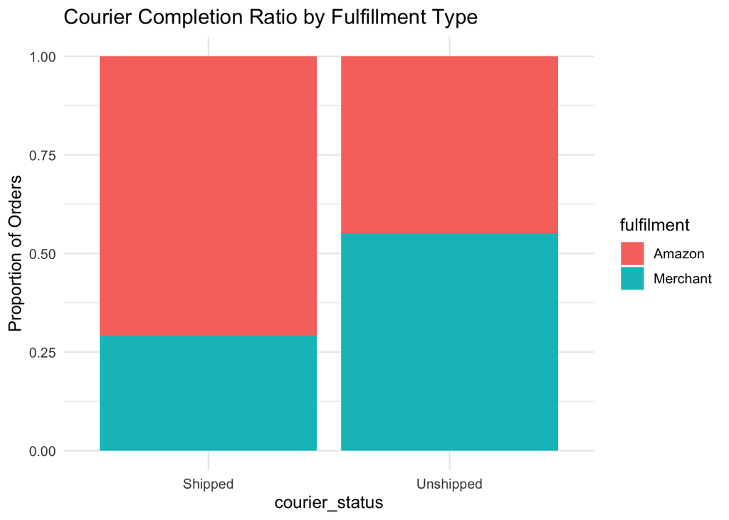

```r
ggplot(ama_success, aes(x = courier_status, fill = fulfilment)) +
  geom_bar(position = "fill") +
  labs(title = "Courier Completion Ratio by Fulfillment Type", y = "Proportion of Orders")
```

#### 6.1.0.1 Order Volume by Fulfillment Method

- The bar chart shows that **Amazon Fulfillment (FBA)** handles **roughly twice as many orders** as Merchant Fulfilled.
- This indicates that most sellers and customers prefer the **Amazon-managed logistics pipeline**, likely due to its convenience, integrated shipping, and faster delivery promise.
- From a business standpoint, this highlights **FBA’s dominance in operational throughput** — Amazon’s fulfillment infrastructure captures the majority of order volume.

#### 6.1.0.3 Courier Completion Ratio by Fulfillment Type

- The proportional stacked bar chart indicates that **Amazon Fulfillment has a higher proportion of shipped (completed) orders**, while **Merchant Fulfilled has more unshipped or pending statuses**.
- This reinforces Amazon’s **operational reliability advantage** — the FBA network achieves **higher on-time shipment rates**, while Merchant sellers may face capacity or coordination delays.

### 6.1.1 Business Implications

Together, these findings directly support the business objective: > **Assess fulfillment performance** — by quantifying FBA vs Merchant trade-offs in order scale, revenue stability, and delivery reliability.

## 6.2 Revenue Distribution by Product Attributes

This section analyzes how **product categories** and **size variants** contribute to overall revenue and sales volume.  
It supports our second business objective: > **Identify revenue distribution:** Determine which product segments generate the highest revenue and demand to guide pricing, inventory, and assortment strategies.

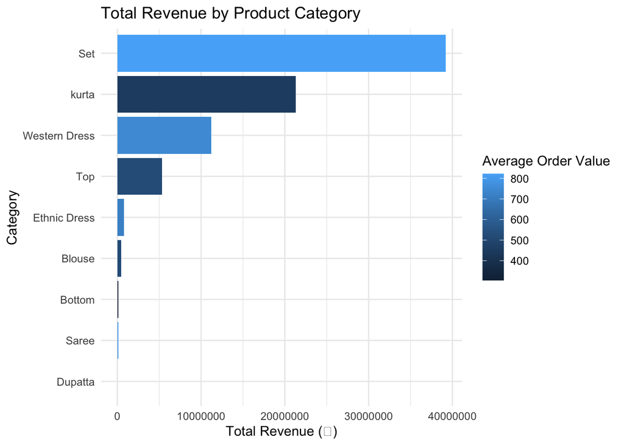

```r
ama_success %>%
  group_by(category) %>%
  summarise(total_sales = sum(amount, na.rm = TRUE),
            avg_order_value = mean(amount, na.rm = TRUE),
            total_qty = sum(qty, na.rm = TRUE)) %>%
  arrange(desc(total_sales)) %>%
  ggplot(aes(x = reorder(category, total_sales), y = total_sales, fill = avg_order_value)) +
  geom_col() + coord_flip() +
  labs(title = "Total Revenue by Product Category",
       x = "Category", y = "Total Revenue (₹)",
       fill = "Average Order Value") +
  theme_minimal()
```

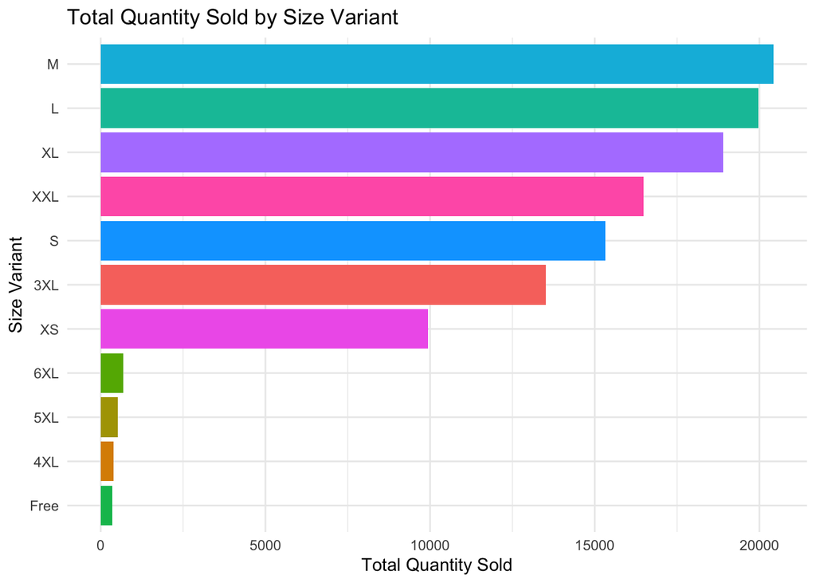

```r
ama_success %>%
  group_by(size) %>%
  summarise(total_qty = sum(qty, na.rm = TRUE)) %>%
  ggplot(aes(x = reorder(size, total_qty), y = total_qty, fill = size)) +
  geom_col(show.legend = FALSE) + coord_flip() +
  labs(title = "Total Quantity Sold by Size Variant",
       x = "Size Variant", y = "Total Quantity Sold") +
  theme_minimal()
```

The analysis highlights clear concentration patterns in both product mix and size demand:

- **Category Insight:**  
  “Set” and “Kurta” categories generate the highest total revenue, indicating their strong market positioning and contribution to top-line performance.  
  *Sets* stand out with a higher average order value (₹800+), suggesting premium pricing and strong customer appeal, while *Kurtas* sustain consistent sales volume through wider accessibility.
- **Size Insight:**  
  The majority of units sold fall within **M, L, and XL** size ranges — the commercial “core” of customer demand.  
  Sales taper off significantly for smaller (XS–S) and extended (3XL+) sizes, which likely have slower turnover and higher holding costs.

**Strategic Implications:**  
- Prioritize marketing, production, and restocking efforts for **Set** and **Kurta** categories.  
- Maintain optimal inventory levels in **M–XL** sizes to match real demand.  
- Streamline or bundle underperforming SKUs to reduce inventory inefficiency.

These insights directly support revenue optimization by focusing resources on the most profitable and fast-moving product segments.

# 7 Phase III: International Sales Dataset

This phase focuses on analyzing the **International Sales (intl_sale)** dataset to understand global sales performance and revenue trends.  
The dataset contains transactional-level export data, including **customer names, dates, SKUs, product sizes, quantities (PCS), rates, and gross amounts**.  
By exploring these variables, this phase aims to uncover key insights into international market behavior and seasonality.

The analysis primarily addresses the following objectives: - **Track international sales trends** over time to identify seasonal fluctuations and peak months.  
- **Measure total sales quantity and revenue** across different customer segments and time periods.  
- **Support business decisions** on export planning, pricing strategy, and inventory allocation for international demand cycles.

This phase transitions from domestic marketplace analysis to global transaction patterns, helping quantify how international operations contribute to overall business profitability.

## 7.1 Monthly Performance Analysis

To understand international market dynamics, this section analyzes **monthly sales and revenue performance** using the `intl_sale` dataset.  
By tracking total **gross revenue** and **quantity sold (PCS)** over time, the goal is to uncover **seasonal trends, export performance cycles, and demand fluctuations**.

This aligns directly with the business objective of identifying **when international markets perform strongest**, supporting data-driven planning for production, inventory, and global marketing strategy.

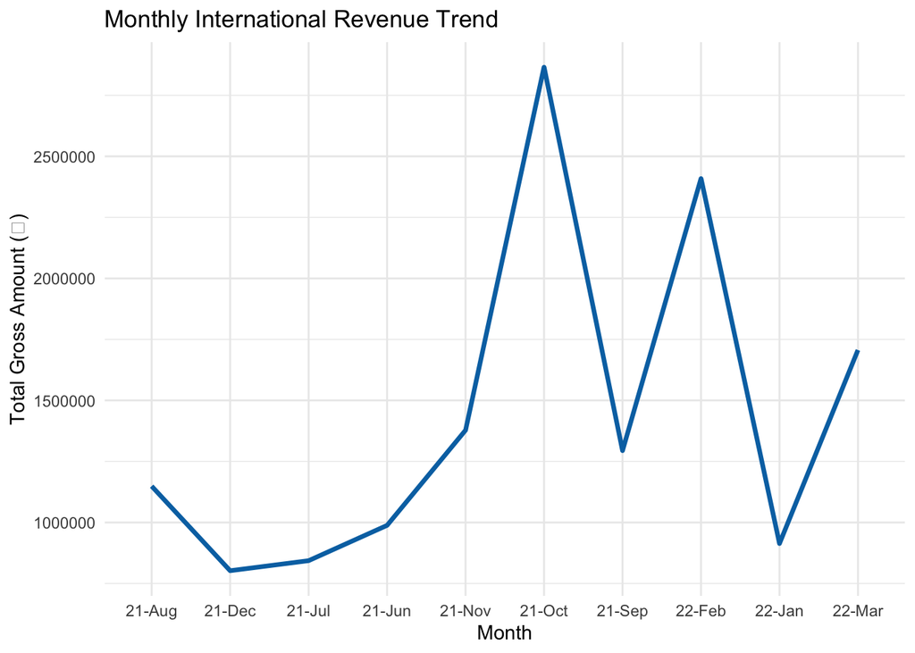

```r
# --- Monthly International Revenue Trend ---
ggplot(intl_sale, aes(x = Months, y = `GROSS AMT`, group = 1)) +
  stat_summary(fun = sum, geom = "line", color = "#0072B2", size = 1.2) +
  labs(title = "Monthly International Revenue Trend",
       x = "Month", y = "Total Gross Amount (₹)") +
  theme_minimal()
```

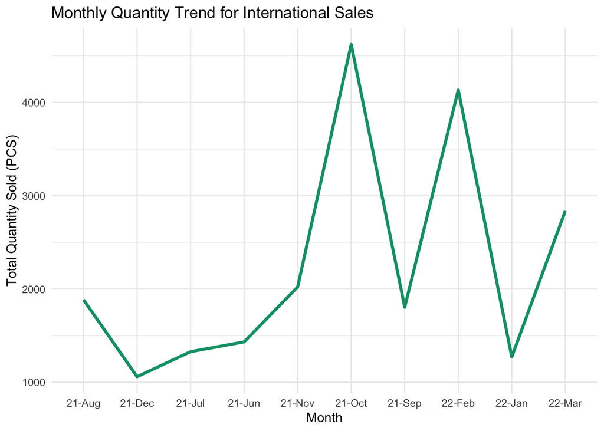

```r
# --- Monthly Quantity Trend for International Sales ---

ggplot(intl_sale, aes(x = Months, y = PCS, group = 1)) +
  stat_summary(fun = sum, geom = "line", color = "#009E73", size = 1.2) +
  labs(
    title = "Monthly Quantity Trend for International Sales",
    x = "Month",
    y = "Total Quantity Sold (PCS)"
  ) +
  theme_minimal()
```

The two trend lines display clear **seasonal patterns** in international sales performance. Both **gross revenue** and **quantity sold (PCS)** follow similar trajectories, peaking during **October** and **February**, with noticeable declines in **December–January**.

- The **parallel movement** between revenue and quantity indicates that higher order volumes directly drive total revenue, implying relatively stable pricing strategies across months.
- The **December–January decline** may reflect seasonal slowdowns in export activity or fulfillment constraints during post-holiday periods.
- The **October surge** suggests a strong pre-holiday or festive season demand, marking it as a critical window for international sales and promotional focus.

From a business standpoint, these insights emphasize the need for **proactive inventory allocation, marketing alignment, and logistical readiness** during high-demand months to capture seasonal revenue spikes efficiently.

## 7.2 Customer-Level Revenue Analysis

To complement the monthly trend analysis, this section focuses on identifying **which international customers generate the highest total revenue**.  
By aggregating sales performance at the customer level, we can pinpoint key buyers driving overall profitability in the international market.

This analysis directly supports the business objective of understanding **revenue concentration and customer dependency** — enabling the company to strengthen relationships with top-performing clients and identify opportunities for market diversification.

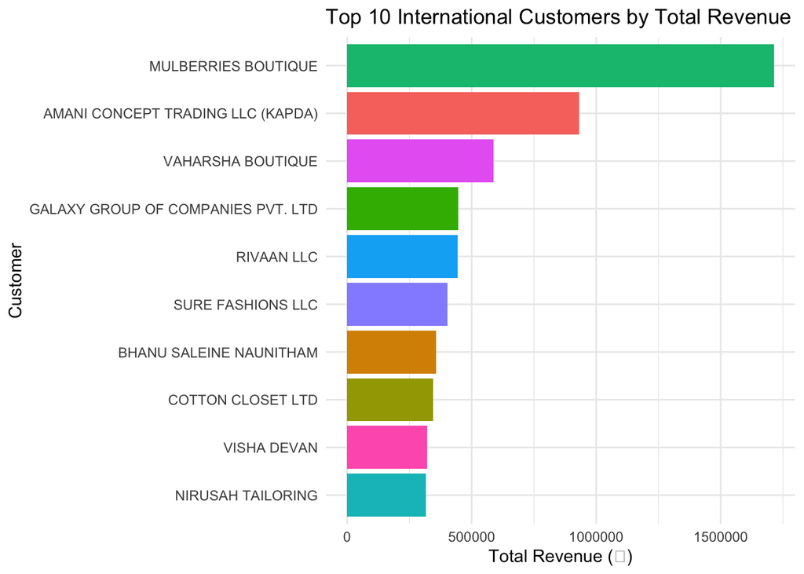

```r
# --- Top International Customers by Total Revenue ---

intl_sale %>%
  group_by(CUSTOMER) %>%
  summarise(total_revenue = sum(`GROSS AMT`, na.rm = TRUE)) %>%
  arrange(desc(total_revenue)) %>%
  slice_head(n = 10) %>%
  ggplot(aes(x = reorder(CUSTOMER, total_revenue), y = total_revenue, fill = CUSTOMER)) +
  geom_col(show.legend = FALSE) +
  coord_flip() +
  labs(
    title = "Top 10 International Customers by Total Revenue",
    x = "Customer",
    y = "Total Revenue (₹)"
  ) +
  theme_minimal()
```

This concentration indicates a **high dependency on a few key accounts**, which underscores the importance of maintaining strong partnerships and consistent service quality for these clients.  
At the same time, expanding outreach to smaller buyers could help **reduce revenue risk and stabilize future growth** in the international segment.

# 8 Overall Business Insight Summary

Across all three datasets—**P&L Combined**, **Amazon Success**, and **International Sales**—the analysis provides a comprehensive view of e-commerce profitability and operational drivers.

## 8.1 P&L Summary — Descriptive + Predictive Insights

**1. Descriptive Analysis — Market & Profitability Patterns**

The descriptive analysis revealed that profitability across platforms, categories, and catalogs is **structurally patterned rather than random or seasonal**.  
- **Platform-Level Trends:** Amazon and Amafba showed the **highest average arbitrage profit margins (~2%)**, followed by Flipkart and Limeroad. Myntra displayed the **lowest margins (~1.1%)**, indicating tighter pricing competition.  
- **Product Categories:** Profit concentration was **category-anchored**, with *Kurta* and *Kurta Sets* consistently outperforming other segments. Margins remained stable between 2021 and 2022, confirming that **time variation contributes little to profit change**.  
- **Catalog Drivers:** Within categories, catalogs such as **Breeze-4**, **Moments**, and **Colors-8** emerged as the **top profit generators**, achieving margins above 5–8%. Others (e.g., Mix, Surmaya) underperformed, showing limited price variation and potential outdated stock.  
- **Cross-Platform Dynamics:** High correlation among major platforms (e.g., Myntra–Paytm–Limeroad, *r* ≈ 0.8–0.9) suggests synchronized price movements and narrow arbitrage gaps. However, moderate divergence on select platforms like Ajio indicates **opportunities for platform-specific pricing differentiation**.

Overall, these findings show that **profitability is catalog-concentrated, category-anchored, and pricing-driven**, forming a structurally stable marketplace with predictable margin behaviors in the 1–2% band.

**2. Predictive Analysis — Model-Based Insights**

The predictive modeling phase deepened these observations by identifying **statistical drivers of profitability** and validating business hypotheses:  
- **Baseline Logistic Regression** confirmed directionality but suffered from **perfect separation and multicollinearity**, producing no real predictive insight.  
- **Regularized Models (LASSO & Ridge)** stabilized estimation and exposed key profitability levers:  
- `price_ratio` (selling-to-cost ratio) as the **dominant positive driver**.  
- `catalog` features (e.g., *Colors-7*, *Rozana*) as **consistent high-margin contributors**.  
- **Decision Tree Analysis** uncovered interpretable **pricing thresholds** (e.g., `amazon_mrp < 2173`, `limeroad_mrp ≥ 2396`) that segment profit outcomes by platform and catalog, laying the foundation for **dynamic pricing strategies**.  
- **Random Forest Ensemble** achieved the most robust results, validating that **historical MRP**, **catalog grouping**, and **Amazon-linked MRPs** are the **core profitability predictors**, while `size_variant` and `year` remain negligible.

This confirms that **profitability is structural, not seasonal**, and primarily depends on *price anchoring, catalog identity, and platform alignment*.

**3. Strategic Takeaways and Business Implications**

Integrating descriptive and predictive findings yields a unified profitability framework for e-commerce decision-making:  
- **Pricing Optimization:** Adjusting `mrp_old` and platform-specific MRP bands (especially Amazon) can directly improve margin yield.  
- **Catalog Management:** Prioritize high-margin catalogs (e.g., *Breeze-4*, *Moments*, *Colors-8*) while auditing or retiring low-margin ones (*Mix*, *Surmaya*).  
- **Cross-Platform Coordination:** Maintain synchronized pricing across high-correlation platforms while exploiting differentiation opportunities where correlation weakens (e.g., Ajio).  
- **Operational Forecasting:** Use Ridge for stability and Random Forest for deployment to continuously forecast and monitor profit drivers.

In essence, the combined P&L analysis establishes a **data-driven profitability intelligence system**, linking descriptive margin behavior with predictive modeling precision — enabling **dynamic pricing, smarter catalog curation, and sustained cross-platform profit resilience**.

## 8.2 Amazon Success Summary — Fulfillment, Product, and Operational Insights

**1. Fulfillment & Sales Behavior**

The Amazon performance analysis demonstrates that **operational fulfillment strategy and product structure** are central to sales stability and customer satisfaction.

**2. Product Performance — Category and Size Dynamics**

Product-level analysis reveals that **sales concentration and inventory efficiency** are driven by a few dominant categories and specific customer size ranges.

- **Category-Level Trends:**  
  *Set* and *Kurta* categories generate the **highest total revenue**, underlining their importance to Amazon’s apparel segment.  
  *Sets* stand out for **premium pricing (₹800+ average order value)** and strong market appeal, while *Kurtas* maintain **consistent high-volume turnover** through affordability and accessibility.
- **Size Distribution Patterns:**  
  The majority of units sold fall within **M, L, and XL**, representing the commercial “core” of active demand. Smaller (XS–S) and extended (3XL–6XL) sizes display limited turnover, indicating potential inventory inefficiencies.

Together, these insights demonstrate that **category leadership and size alignment** are key drivers of sustained revenue growth within Amazon’s apparel ecosystem.

**3. Strategic Takeaways and Business Implications**

In essence, Amazon’s success model combines **fulfillment excellence, demand-driven product strategy, and category leadership** — delivering a unified approach to **revenue optimization, reliability, and long-term operational efficiency**.

## 8.3 International Sales Summary — Seasonal Performance and Client Concentration

**1. Seasonal Trends and Revenue Behavior**

The international dataset reveals **distinct seasonal fluctuations** in both total revenue and quantity sold, reflecting cyclical export demand patterns.  
- **Monthly Trends:** Revenue and quantity trajectories move in parallel, peaking notably in **October** and **February**, followed by sharp declines in **December–January**. This synchronicity suggests that sales volume directly drives revenue, indicating **stable and consistent pricing strategies**.  
- **Seasonal Interpretation:**  
- The **October surge** likely corresponds to pre-holiday or festival-related bulk orders.  
- The **February rebound** may reflect replenishment cycles or post-season trade resumption.  
- The **December–January trough** indicates export slowdowns, possibly due to logistical congestion or reduced market activity post-holidays.

Overall, these patterns demonstrate that **international performance is seasonally driven**, with predictable high-demand windows and temporary slowdowns shaped by global retail cycles.

**2. Customer Portfolio — Revenue Concentration and Dependency Risk**

### 8.3.1 **3. Strategic Takeaways and Business Implications**

Combining seasonal and client-level insights establishes a clear operational focus for sustaining growth and mitigating volatility:  
- **Seasonal Readiness:** Align inventory buildup, logistics scheduling, and export documentation to **anticipate October and February surges**, ensuring stock availability and timely fulfillment.  
- **Client Retention:** Deepen engagement with top-tier clients through loyalty programs, early-bird seasonal offers, and co-marketing collaborations to maintain volume commitments.  
- **Revenue Diversification:** Expand outreach to mid-tier and smaller international buyers to **broaden the revenue base** and stabilize long-term growth against concentration risks.  
- **Operational Forecasting:** Integrate these temporal and client insights into sales forecasting models to optimize demand planning and working capital allocation.

In summary, the international sales division operates within a **predictable, seasonally fluctuating ecosystem** — driven by a small but powerful buyer network. Strategic balancing between **seasonal agility and client diversification** will be essential for maintaining profitability and resilience in future cycles.

# 9 Final Conclusion — Integrated Business Intelligence Outlook

The combined P&L, Amazon, and International analyses converge on a unified theme:  
**profitability and sales performance in the e-commerce ecosystem are structurally determined, operationally anchored, and predictably cyclical.**

Across all datasets, three cross-cutting principles emerge:

1. **Structural Profitability Stability:**  
   Profit margins are not random or seasonal but consistently shaped by platform economics, catalog identity, and price anchoring.  
   Predictive models reinforce this by confirming that historical MRP and catalog grouping remain the strongest profitability predictors, enabling precise profit forecasting and margin control.
2. **Operational Excellence through Fulfillment Strategy:**  
   Amazon’s FBA network exemplifies the operational gold standard — scalability, reliability, and fulfillment speed directly translate into revenue consistency and customer trust.  
   Leveraging FBA while strategically positioning Merchant Fulfilled operations for flexible or region-specific inventory provides an optimal hybrid model balancing efficiency and adaptability.
3. **Market Responsiveness and Seasonal Adaptation:**  
   International sales exhibit cyclic surges tied to retail and festival calendars (October–February), underscoring the need for agile inventory buildup, export scheduling, and capacity management during peak months.  
   These cycles are predictable, allowing proactive forecasting rather than reactive adjustment.

### 9.0.1 Strategic Integration

When synthesized, these insights form a **data-driven operational intelligence framework** for decision-makers: - **Dynamic Pricing:** Employ predictive thresholds and platform-specific MRP tuning to sustain competitive yet profitable pricing strategies.  
- **Catalog & Inventory Prioritization:** Concentrate capital and marketing efforts on proven high-margin catalogs (*Breeze-4*, *Moments*, *Colors-8*) and dominant categories (*Set*, *Kurta*), while systematically phasing out underperforming SKUs.  
- **Cross-Platform & Cross-Market Coordination:** Align domestic and international operations by using Amazon FBA’s reliability as a template for export readiness and multi-market standardization.  
- **Client and Revenue Diversification:** Mitigate dependency risk in international trade by cultivating secondary and emerging buyers, stabilizing long-term export growth.

### 9.0.2 Forward Outlook

The project establishes a scalable analytical foundation — one that links **descriptive pattern discovery, predictive modeling, and operational application** into a single performance ecosystem.  
Future work can extend this framework toward: - Real-time profit monitoring dashboards using **automated Random Forest pipelines**;  
- Demand forecasting through **time-series and seasonal ARIMA models**;  
- and integrated pricing simulators for multi-platform synchronization.

Ultimately, the findings confirm that **sustainable profitability in e-commerce emerges not from chance, but from data discipline** — where each operational layer, from pricing to fulfillment, reinforces a self-correcting, insight-driven business model built for long-term growth.